# try-jsr

2024-07-26

## R code successfully generates a histogram to visualize the number of differentially phosphorylated sites for each type of phosphorylated residue in the dataset.

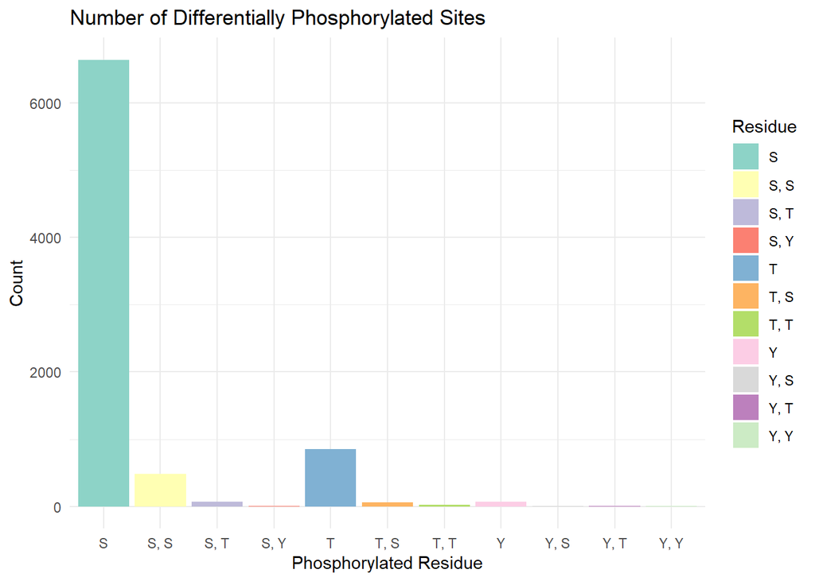

```r
# Load necessary libraries
library(readxl)
library(ggplot2)
library(RColorBrewer)

# Load the Excel file
file_path <- "C:/Users/avani/Downloads/Final_Cleaned_Data.xlsx"
data <- read_excel(file_path)

# Count the occurrences of each phosphorylated residue type
residue_counts <- table(data$New_Phosphorylated_Residue)

# Convert to a data frame for ggplot2
residue_counts_df <- as.data.frame(residue_counts)
colnames(residue_counts_df) <- c("Residue", "Count")

# Determine the number of unique residues
num_residues <- length(unique(data$New_Phosphorylated_Residue))

# Generate a color palette with enough colors
custom_colors <- brewer.pal(num_residues, "Set3")

# Create the histogram with custom colors
ggplot(residue_counts_df, aes(x = Residue, y = Count, fill = Residue)) +
  geom_bar(stat = "identity") +
  scale_fill_manual(values = custom_colors) +
  labs(x = "Phosphorylated Residue", y = "Count", title = "Number of Differentially Phosphorylated Sites") +
  theme_minimal()
```

## Logfold change along with certain and uncertain value

## The results highlight how phosphorylation events vary in their certainty and complexity.

## This analysis sets the stage for how specific phosphorylation patterns influence gene function and contribute to cellular behavior.

```r
library(readxl)

# Load the data
file_path <- "C://Users//avani//Downloads//Final_Cleaned_Data.xlsx"  # Update with your file path
data <- read_excel(file_path)

# Clean the data for leading/trailing spaces
data$Old_Phos_Positions <- trimws(data$Old_Phos_Positions)

# Function to count genes matching a target pattern
count_genes_with_pattern <- function(pattern) {
  has_pattern <- function(mods) {
    if (is.na(mods)) {
      return(FALSE)  # Return FALSE if there are no values
    }
    return(grepl(pattern, mods))
  }
  genes_with_pattern <- sapply(data$Old_Phos_Positions, has_pattern)
  return(sum(genes_with_pattern))
}

# Define target patterns
patterns <- c(
  "Phospho@\\d+=\\d+;",                           # One certain value
  "Phospho@\\d+=\\d+;Phospho@\\d+=\\d+;",         # Two certain values
  "Phospho@\\d+\\|\\d+;",                         # One uncertain value
  "Phospho@\\d+\\|\\d+\\|\\d+;",                  # Two uncertain values
  "Phospho@\\d+\\|\\d+\\|\\d+\\|\\d+;",           # Three uncertain values
  "Phospho@\\d+\\|\\d+\\|\\d+\\|\\d+\\|\\d+;",    # Four uncertain values
  "Phospho@\\d+\\|\\d+\\|\\d+\\|\\d+\\|\\d+\\|\\d+;",  # Five uncertain values
  "Phospho@\\d+\\|\\d+\\|\\d+\\|\\d+\\|\\d+\\|\\d+\\|\\d+;"  # Six uncertain values
)

# Calculate and display totals for each pattern
for (pattern in patterns) {
  total_genes <- count_genes_with_pattern(pattern)
  cat("Total number of genes with pattern", pattern, ":", total_genes, "\n")
}
```

```
## Total number of genes with pattern Phospho@\d+=\d+; : 4438
## Total number of genes with pattern Phospho@\d+=\d+;Phospho@\d+=\d+; : 193
## Total number of genes with pattern Phospho@\d+\|\d+; : 1969
## Total number of genes with pattern Phospho@\d+\|\d+\|\d+; : 622
## Total number of genes with pattern Phospho@\d+\|\d+\|\d+\|\d+; : 235
## Total number of genes with pattern Phospho@\d+\|\d+\|\d+\|\d+\|\d+; : 83
## Total number of genes with pattern Phospho@\d+\|\d+\|\d+\|\d+\|\d+\|\d+; : 44
## Total number of genes with pattern Phospho@\d+\|\d+\|\d+\|\d+\|\d+\|\d+\|\d+; : 18
```

## Bar Graph along with certain and uncertain value

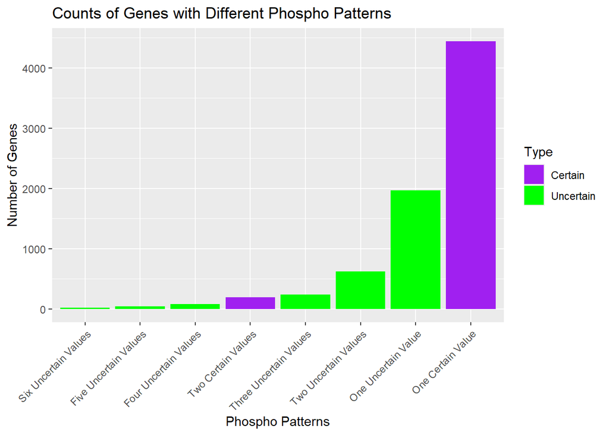

```r
library(readxl)
library(ggplot2)

# Load the data
file_path <- "C://Users//avani//Downloads//Final_Cleaned_Data.xlsx"  # Update with your file path
data <- read_excel(file_path)

# Clean the data for leading/trailing spaces
data$Old_Phos_Positions <- trimws(data$Old_Phos_Positions)

# Function to count genes matching a target pattern
count_genes_with_pattern <- function(pattern) {
  has_pattern <- function(mods) {
    if (is.na(mods)) {
      return(FALSE)  # Return FALSE if there are no values
    }
    return(grepl(pattern, mods))
  }
  genes_with_pattern <- sapply(data$Old_Phos_Positions, has_pattern)
  return(sum(genes_with_pattern))
}

# Define target patterns
patterns <- c(
  "Phospho@\\d+=\\d+;",                           # One certain value
  "Phospho@\\d+=\\d+;Phospho@\\d+=\\d+;",         # Two certain values
  "Phospho@\\d+\\|\\d+;",                         # One uncertain value
  "Phospho@\\d+\\|\\d+\\|\\d+;",                  # Two uncertain values
  "Phospho@\\d+\\|\\d+\\|\\d+\\|\\d+;",           # Three uncertain values
  "Phospho@\\d+\\|\\d+\\|\\d+\\|\\d+\\|\\d+;",    # Four uncertain values
  "Phospho@\\d+\\|\\d+\\|\\d+\\|\\d+\\|\\d+\\|\\d+;",  # Five uncertain values
  "Phospho@\\d+\\|\\d+\\|\\d+\\|\\d+\\|\\d+\\|\\d+\\|\\d+;"  # Six uncertain values
)

# Calculate counts for each pattern
counts <- sapply(patterns, count_genes_with_pattern)

# Prepare data for plotting
plot_data <- data.frame(
  Pattern = c(
    "One Certain Value", "Two Certain Values",
    "One Uncertain Value", "Two Uncertain Values",
    "Three Uncertain Values", "Four Uncertain Values",
    "Five Uncertain Values", "Six Uncertain Values"
  ),
  Count = counts,
  Type = c(
    "Certain", "Certain",
    "Uncertain", "Uncertain",
    "Uncertain", "Uncertain",
    "Uncertain", "Uncertain"
  )
)

# Set colors for the plot
colors <- c("Certain" = "purple", "Uncertain" = "green")

# Plot the bar graph
ggplot(plot_data, aes(x = reorder(Pattern, Count), y = Count, fill = Type)) +
  geom_bar(stat = "identity") +
  scale_fill_manual(values = colors) +
  labs(x = "Phospho Patterns", y = "Number of Genes", title = "Counts of Genes with Different Phospho Patterns") +
  theme(axis.text.x = element_text(angle = 45, hjust = 1))  # Optional: for better readability of x-axis labels
```

## EG1 to LG1 phase For ERK1

## its effectively analyzes and visualizes phosphorylation changes in the ERK signaling pathway genes during the transition from early G1 (eG1) to late G1 (LG1) phases of the cell cycle.

## in the plot, each dot represents a specific measurement of phosphorylation levels at a particular site on the Mapk1”, “Mapk3”, “Raf1”, “Braf”, “Map2k1”, “Map2k2” protein during different phases of the cell cycle (early G1 and late G1), etc..

## Each facet of the plot corresponds to a different protine (e.g., BRAF, MAP2K2). This means we can directly compare how phosphorylation levels of each specific protine change across the phases.

## The y-axis value of each dot indicates the level of phosphorylation for that site. A higher value suggests more phosphorylation at that site, which can be interpreted as higher activation or activity at that particular phosphorylation site.

## The protine present in our dataset are Braf, Map2k2, and Raf1, which matches ERK signaling protine of interest.

```r
# Load necessary libraries
library(reshape2) # For melt function
library(ggplot2) # For ggplot2

# Load the data
data <- read.csv("C:/Users/avani/Downloads/Updated_Data_Mutated-June24.csv")

# Define ERK signaling genes of interest
erk_signaling_genes <- c("Mapk1", "Mapk3", "Raf1", "Braf", "Map2k1", "Map2k2")

# Extract phosphorylation data for ERK signaling genes
phospho_data_erk <- data[data$Gene %in% erk_signaling_genes, ]

# Define the phases of interest (eG1 to LG1)
phases_of_interest <- c("phase_earlyG1_A", "phase_earlyG1_B", "phase_earlyG1_C",
                        "phase_lateG1_A", "phase_lateG1_B", "phase_lateG1_C")

# Prepare the data for plotting
phospho_data_long_erk <- melt(phospho_data_erk,
                               id.vars = c("Gene", "New_Gene_Residue"),
                               measure.vars = phases_of_interest,
                               variable.name = "Phase", value.name = "Phosphorylation")

# Create a new column to categorize phases into eG1 and LG1
phospho_data_long_erk$PhaseCategory <- ifelse(grepl("earlyG1", phospho_data_long_erk$Phase), "eG1",
                                               ifelse(grepl("lateG1", phospho_data_long_erk$Phase), "LG1", NA))

# Handle missing values by imputing with column means
phospho_data_long_erk$Phosphorylation[is.na(phospho_data_long_erk$Phosphorylation)] <-
  ave(phospho_data_long_erk$Phosphorylation, phospho_data_long_erk$Phase, FUN = function(x) mean(x, na.rm = TRUE))

# Check the PhaseCategory column and filter out NA values
table(phospho_data_long_erk$PhaseCategory)
```

```
##
## eG1 LG1
##  12  12
```

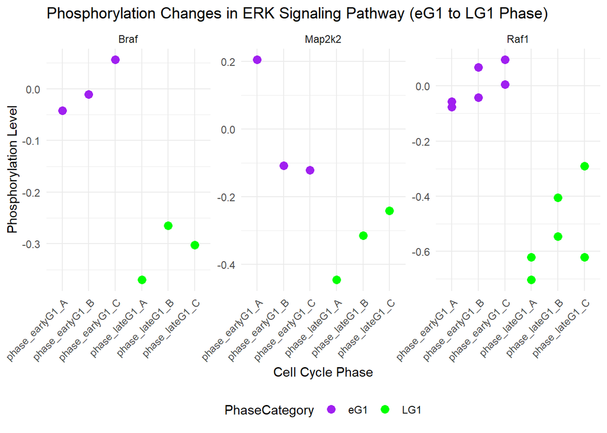

```r
phospho_data_long_erk <- phospho_data_long_erk[!is.na(phospho_data_long_erk$PhaseCategory), ]

# Plot phosphorylation changes for ERK signaling
ggplot(phospho_data_long_erk, aes(x = Phase, y = Phosphorylation, color = PhaseCategory)) +
  geom_point(size = 3) +
  facet_wrap(~ Gene, scales = "free_y") +
  labs(title = "Phosphorylation Changes in ERK Signaling Pathway (eG1 to LG1 Phase)",
       x = "Cell Cycle Phase",
       y = "Phosphorylation Level") +
  scale_color_manual(values = c("eG1" = "purple", "LG1" = "green")) +
  theme_minimal() +
  theme(axis.text.x = element_text(angle = 45, hjust = 1),
        legend.position = "bottom")
```

## LG1 to S Phase For ERK1

```r
# Load necessary libraries
library(reshape2) # For melt function
library(ggplot2) # For ggplot2

# Load the data
data <- read.csv("C:/Users/avani/Downloads/Updated_Data_Mutated-June24.csv")

# Define ERK signaling genes of interest
erk_signaling_genes <- c("Mapk1", "Mapk3", "Raf1", "Braf", "Map2k1", "Map2k2")

# Extract phosphorylation data for ERK signaling genes
phospho_data_erk <- data[data$Gene %in% erk_signaling_genes, ]

# Define the phases of interest (LG1 to S)
phases_of_interest <- c("phase_lateG1_A", "phase_lateG1_B", "phase_lateG1_C",
                        "phase_S_A", "phase_S_B", "phase_S_C")

# Prepare the data for plotting
phospho_data_long_erk <- melt(phospho_data_erk,
                              id.vars = c("Gene", "New_Gene_Residue"),
                              measure.vars = phases_of_interest,
                              variable.name = "Phase", value.name = "Phosphorylation")

# Create a new column to categorize phases into LG1 and S
phospho_data_long_erk$PhaseCategory <- ifelse(grepl("lateG1", phospho_data_long_erk$Phase), "LG1",
                                              ifelse(grepl("S", phospho_data_long_erk$Phase), "S", NA))

# Handle missing values by imputing with column means
phospho_data_long_erk$Phosphorylation[is.na(phospho_data_long_erk$Phosphorylation)] <-
  ave(phospho_data_long_erk$Phosphorylation, phospho_data_long_erk$Phase, FUN = function(x) mean(x, na.rm = TRUE))

# Check the PhaseCategory column and filter out NA values
table(phospho_data_long_erk$PhaseCategory)
```

```
##
## LG1   S
##  12  12
```

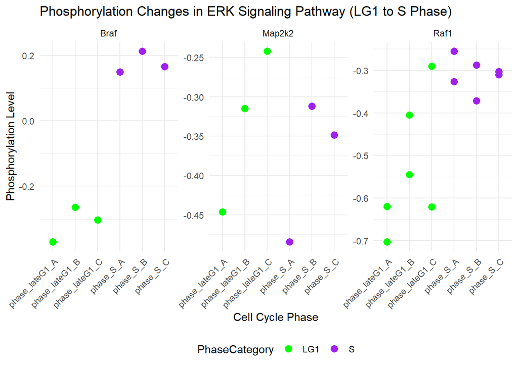

```r
phospho_data_long_erk <- phospho_data_long_erk[!is.na(phospho_data_long_erk$PhaseCategory), ]

# Plot phosphorylation changes for ERK signaling
ggplot(phospho_data_long_erk, aes(x = Phase, y = Phosphorylation, color = PhaseCategory)) +
  geom_point(size = 3) +
  facet_wrap(~ Gene, scales = "free_y") +
  labs(title = "Phosphorylation Changes in ERK Signaling Pathway (LG1 to S Phase)",
       x = "Cell Cycle Phase",
       y = "Phosphorylation Level") +
  scale_color_manual(values = c("LG1" = "green", "S" = "purple")) +
  theme_minimal() +
  theme(axis.text.x = element_text(angle = 45, hjust = 1),
        legend.position = "bottom")
```

## ERk1 S to M phase For ERK1

```r
# Load necessary libraries
library(reshape2) # For melt function
library(ggplot2) # For ggplot2

# Load the data
data <- read.csv("C:/Users/avani/Downloads/Updated_Data_Mutated-June24.csv")

# Define ERK signaling genes of interest
erk_signaling_genes <- c("Mapk1", "Mapk3", "Raf1", "Braf", "Map2k1", "Map2k2")

# Extract phosphorylation data for ERK signaling genes
phospho_data_erk <- data[data$Gene %in% erk_signaling_genes, ]

# Define the phases of interest (S to M)
phases_of_interest <- c("phase_S_A", "phase_S_B", "phase_S_C",
                        "phase_M_A", "phase_M_B", "phase_M_C")

# Prepare the data for plotting
phospho_data_long_erk <- melt(phospho_data_erk,
                               id.vars = c("Gene", "New_Gene_Residue"),
                               measure.vars = phases_of_interest,
                               variable.name = "Phase", value.name = "Phosphorylation")

# Create a new column to categorize phases into S and M
phospho_data_long_erk$PhaseCategory <- ifelse(grepl("S", phospho_data_long_erk$Phase), "S",
                                               ifelse(grepl("M", phospho_data_long_erk$Phase), "M", NA))

# Handle missing values by imputing with column means
phospho_data_long_erk$Phosphorylation[is.na(phospho_data_long_erk$Phosphorylation)] <-
  ave(phospho_data_long_erk$Phosphorylation, phospho_data_long_erk$Phase, FUN = function(x) mean(x, na.rm = TRUE))

# Check the PhaseCategory column and filter out NA values
table(phospho_data_long_erk$PhaseCategory)
```

```
##
##  M  S
## 12 12
```

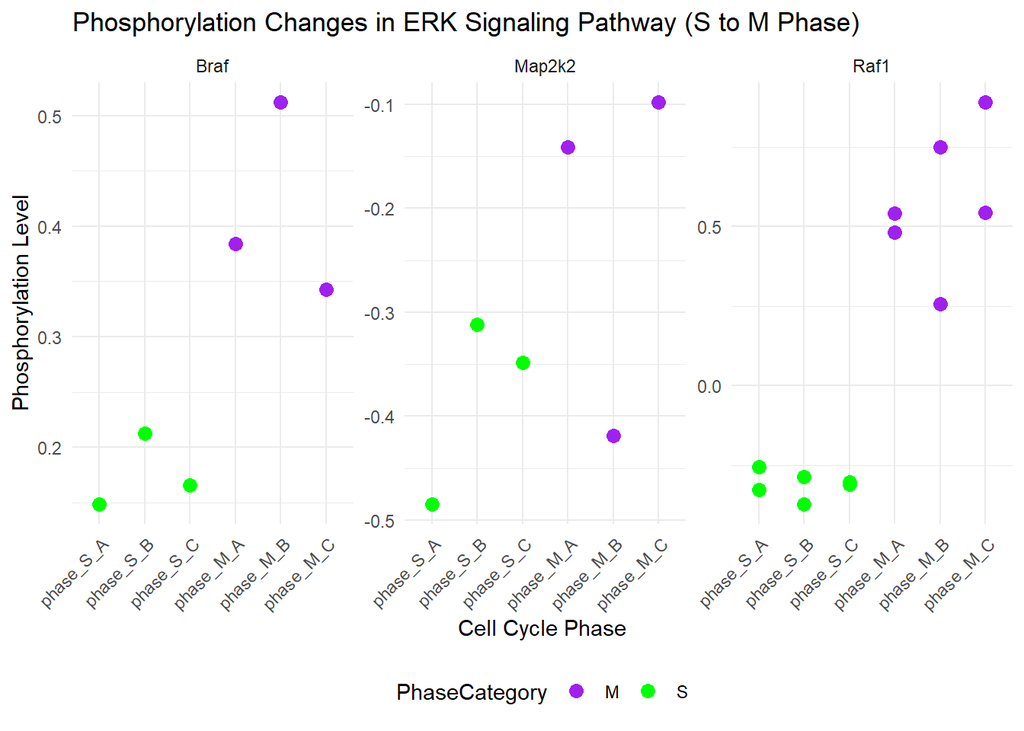

```r
phospho_data_long_erk <- phospho_data_long_erk[!is.na(phospho_data_long_erk$PhaseCategory), ]

# Plot phosphorylation changes for ERK signaling
ggplot(phospho_data_long_erk, aes(x = Phase, y = Phosphorylation, color = PhaseCategory)) +
  geom_point(size = 3) +
  facet_wrap(~ Gene, scales = "free_y") +
  labs(title = "Phosphorylation Changes in ERK Signaling Pathway (S to M Phase)",
       x = "Cell Cycle Phase",
       y = "Phosphorylation Level") +
  scale_color_manual(values = c("S" = "green", "M" = "purple")) +
  theme_minimal() +
  theme(axis.text.x = element_text(angle = 45, hjust = 1),
        legend.position = "bottom")
```

## ERK1 for M to LG1 phase

```r
# Load necessary libraries
library(reshape2) # For melt function
library(ggplot2) # For ggplot2

# Load the data
data <- read.csv("C:/Users/avani/Downloads/Updated_Data_Mutated-June24.csv")

# Define ERK signaling genes of interest
erk_signaling_genes <- c("Mapk1", "Mapk3", "Raf1", "Braf", "Map2k1", "Map2k2")

# Extract phosphorylation data for ERK signaling genes
phospho_data_erk <- data[data$Gene %in% erk_signaling_genes, ]

# Define the phases of interest (M to LG1)
phases_of_interest <- c("phase_M_A", "phase_M_B", "phase_M_C",
                        "phase_lateG1_A", "phase_lateG1_B", "phase_lateG1_C")

# Prepare the data for plotting
phospho_data_long_erk <- melt(phospho_data_erk,
                               id.vars = c("Gene", "New_Gene_Residue"),
                               measure.vars = phases_of_interest,
                               variable.name = "Phase", value.name = "Phosphorylation")

# Create a new column to categorize phases into M and LG1
phospho_data_long_erk$PhaseCategory <- ifelse(grepl("M", phospho_data_long_erk$Phase), "M",
                                               ifelse(grepl("lateG1", phospho_data_long_erk$Phase), "LG1", NA))

# Handle missing values by imputing with column means
phospho_data_long_erk$Phosphorylation[is.na(phospho_data_long_erk$Phosphorylation)] <-
  ave(phospho_data_long_erk$Phosphorylation, phospho_data_long_erk$Phase, FUN = function(x) mean(x, na.rm = TRUE))

# Check the PhaseCategory column and filter out NA values
table(phospho_data_long_erk$PhaseCategory)
```

```
##
## LG1   M
##  12  12
```

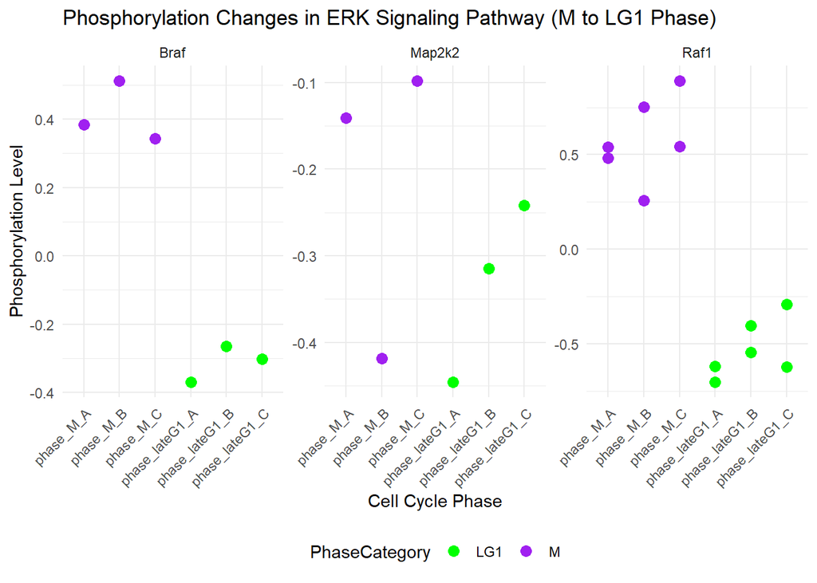

```r
phospho_data_long_erk <- phospho_data_long_erk[!is.na(phospho_data_long_erk$PhaseCategory), ]

# Plot phosphorylation changes for ERK signaling
ggplot(phospho_data_long_erk, aes(x = Phase, y = Phosphorylation, color = PhaseCategory)) +
  geom_point(size = 3) +
  facet_wrap(~ Gene, scales = "free_y") +
  labs(title = "Phosphorylation Changes in ERK Signaling Pathway (M to LG1 Phase)",
       x = "Cell Cycle Phase",
       y = "Phosphorylation Level") +
  scale_color_manual(values = c("M" = "purple", "LG1" = "green")) +
  theme_minimal() +
  theme(axis.text.x = element_text(angle = 45, hjust = 1),
        legend.position = "bottom")
```

## phospho related sites among all phases for ERK

```r
## Load necessary libraries
library(reshape2)
library(ggplot2)
library(ComplexHeatmap)
library(circlize)
# Load the data
data <- read.csv("C:/Users/avani/Downloads/Updated_Data_Mutated-June24.csv")

# Define ERK signaling genes
erk_signaling_genes <- c("Mapk1", "Mapk3", "Raf1", "Braf", "Map2k1", "Map2k2")

# Extract phosphorylation data for ERK signaling genes
phospho_data_erk <- data[data$Gene %in% erk_signaling_genes, ]

# Check if data is extracted properly
print(phospho_data_erk)
```

```
##                       PhosR_Rownames   Gene Start End Length
## 1324  P28028;BRAF;S135;SRNNPKSPQKPIV   Braf   131 142     11
## 3538 Q63932;MAP2K2;T17;ALTINPTIAEGPS Map2k2     6  39     33
## 6766   Q99N57;RAF1;T49;SDDGKLTDSSKTS   Raf1    48  59     11
## 6767  Q99N57;RAF1;T638;EDINACTLTTSPR   Raf1   628 644     16
##                              DB_Peptide  Expect total_P  phase_M_A  phase_M_B
## 1324                       NNPKSPQKPIVR 1.1e-05       1  0.3842533  0.5120288
## 3538 KPVLPALTINPTIAEGPSPTSEGASEANLVDLQK 6.4e-07       1 -0.1411477 -0.4186725
## 6766                       LTDSSKTSNTIR 1.5e-05       1  0.4820688  0.2581576
## 6767                  AAHTEDINACTLTTSPR 2.3e-09       1  0.5409289  0.7503041
##        phase_M_C  phase_M_D phase_earlyG1_A phase_earlyG1_B phase_earlyG1_C
## 1324  0.34286831  0.5765890     -0.04221281     -0.01082468     0.056058581
## 3538 -0.09812386 -0.1624508      0.20408155     -0.10873458    -0.121463391
## 6766  0.54338942  0.8882192     -0.05697007     -0.04241735     0.094496313
## 6767  0.89003411  1.0086482     -0.07605807      0.06743093     0.005047515
```

[output cut: 60 more lines]

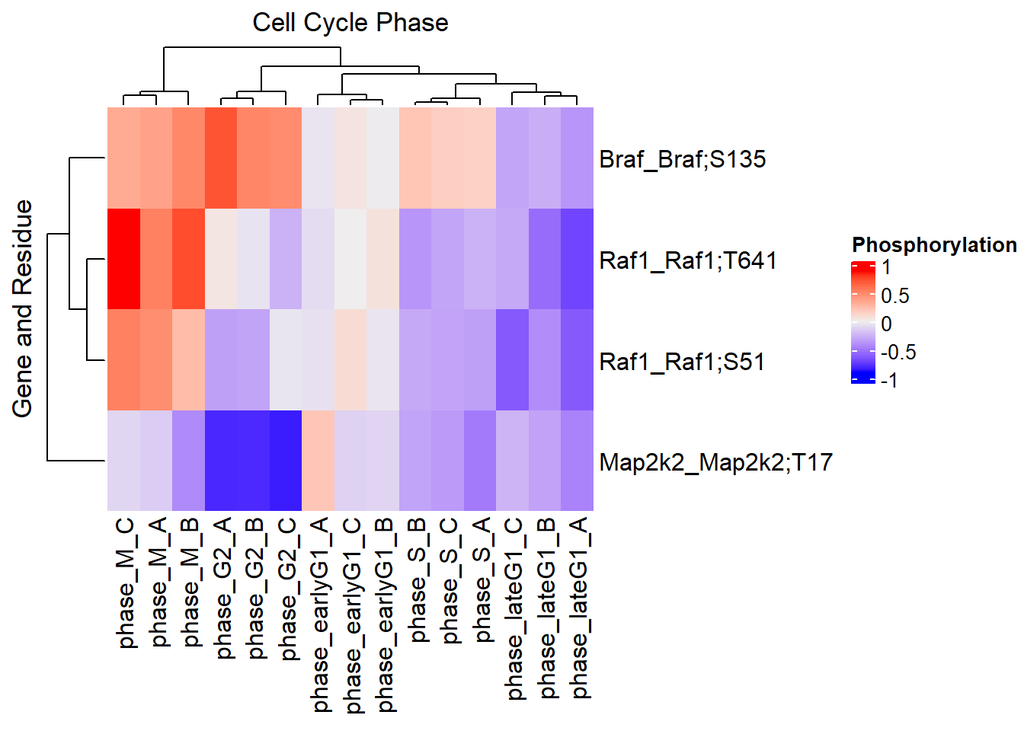

```r
# If the data frame is empty, stop here and print a message
if (nrow(phospho_data_erk) == 0) {
  stop("No data found for the specified ERK signaling genes.")
}

# Define all phases of interest
phases_of_interest <- c("phase_earlyG1_A", "phase_earlyG1_B", "phase_earlyG1_C",
                        "phase_lateG1_A", "phase_lateG1_B", "phase_lateG1_C",
                        "phase_S_A", "phase_S_B", "phase_S_C",
                        "phase_G2_A", "phase_G2_B", "phase_G2_C",
                        "phase_M_A", "phase_M_B", "phase_M_C")

# Prepare the data for heatmap
phospho_data_wide_erk <- phospho_data_erk[, c("Gene", "New_Gene_Residue", phases_of_interest)]
phospho_matrix_erk <- as.matrix(phospho_data_wide_erk[,-(1:2)])
rownames(phospho_matrix_erk) <- paste(phospho_data_wide_erk$Gene, phospho_data_wide_erk$New_Gene_Residue, sep = "_")

# Create a heatmap for ERK signaling genes
Heatmap(
  phospho_matrix_erk,
  name = "Phosphorylation",
  cluster_rows = TRUE,
  cluster_columns = TRUE,
  show_row_names = TRUE,
  show_column_names = TRUE,
  column_title = "Cell Cycle Phase",
  row_title = "Gene and Residue",
  color = colorRamp2(c(min(phospho_matrix_erk, na.rm = TRUE), 0, max(phospho_matrix_erk, na.rm = TRUE)), c("blue", "white", "red"))
)
```

```r
# Prepare the data for plotting
phospho_data_long_erk <- melt(phospho_data_erk,
                              id.vars = c("Gene", "New_Gene_Residue"),
                              measure.vars = phases_of_interest,
                              variable.name = "Phase", value.name = "Phospho_Values")

# Create a new column to categorize phases
phospho_data_long_erk$PhaseCategory <- ifelse(grepl("earlyG1", phospho_data_long_erk$Phase), "earlyG1",
                                              ifelse(grepl("lateG1", phospho_data_long_erk$Phase), "lateG1",
                                                     ifelse(grepl("S", phospho_data_long_erk$Phase), "S",
                                                            ifelse(grepl("G2", phospho_data_long_erk$Phase), "G2",
                                                                   ifelse(grepl("M", phospho_data_long_erk$Phase), "M", NA)))))

# Handle missing values by imputing with column means
phospho_data_long_erk$Phospho_Values[is.na(phospho_data_long_erk$Phospho_Values)] <-
  ave(phospho_data_long_erk$Phospho_Values, phospho_data_long_erk$Phase, FUN = function(x) mean(x, na.rm = TRUE))

# Check the final data for plotting
print(phospho_data_long_erk)
```

```
##      Gene New_Gene_Residue           Phase Phospho_Values PhaseCategory
## 1    Braf        Braf;S135 phase_earlyG1_A   -0.042212810       earlyG1
## 2  Map2k2       Map2k2;T17 phase_earlyG1_A    0.204081548       earlyG1
## 3    Raf1         Raf1;S51 phase_earlyG1_A   -0.056970073       earlyG1
## 4    Raf1        Raf1;T641 phase_earlyG1_A   -0.076058066       earlyG1
## 5    Braf        Braf;S135 phase_earlyG1_B   -0.010824680       earlyG1
## 6  Map2k2       Map2k2;T17 phase_earlyG1_B   -0.108734577       earlyG1
## 7    Raf1         Raf1;S51 phase_earlyG1_B   -0.042417351       earlyG1
## 8    Raf1        Raf1;T641 phase_earlyG1_B    0.067430928       earlyG1
## 9    Braf        Braf;S135 phase_earlyG1_C    0.056058581       earlyG1
## 10 Map2k2       Map2k2;T17 phase_earlyG1_C   -0.121463391       earlyG1
## 11   Raf1         Raf1;S51 phase_earlyG1_C    0.094496313       earlyG1
## 12   Raf1        Raf1;T641 phase_earlyG1_C    0.005047515       earlyG1
## 13   Braf        Braf;S135  phase_lateG1_A   -0.369868059        lateG1
## 14 Map2k2       Map2k2;T17  phase_lateG1_A   -0.446032085        lateG1
```

[output cut: 46 more lines]

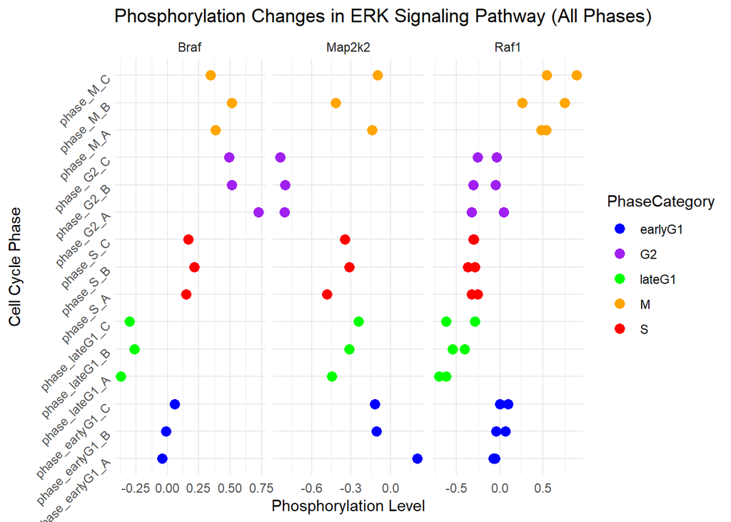

```r
# Plot phosphorylation changes for ERK signaling
ggplot(phospho_data_long_erk, aes(y = Phase, x = Phospho_Values, color = PhaseCategory)) +
  geom_point(size = 3) +
  facet_wrap(~ Gene, scales = "free_x") +
  labs(title = "Phosphorylation Changes in ERK Signaling Pathway (All Phases)",
       y = "Cell Cycle Phase",
       x = "Phosphorylation Level") +
  scale_color_manual(values = c("earlyG1" = "blue", "lateG1" = "green", "S" = "red", "G2" = "purple", "M" = "orange")) +
  theme_minimal() +
  theme(axis.text.y = element_text(angle = 45, hjust = 1),
        legend.position = "right")
```

```r
# Function to print phosphorylation sites and their levels for each gene
print_gene_phospho_sites <- function(gene) {
  gene_data <- phospho_data_long_erk[phospho_data_long_erk$Gene == gene, ]
  gene_sites <- unique(gene_data$New_Gene_Residue)

  cat("Number of unique phosphorylation sites for", gene, ":", length(gene_sites), "\n")
  cat("Phosphorylation sites for", gene, ":\n")
  print(gene_sites)

  cat("Phosphorylation levels by phase for", gene, ":\n")
  print(gene_data)
  cat("\n\n")
}

# Print phosphorylation sites and their levels for each ERK signaling gene
for (gene in erk_signaling_genes) {
  print_gene_phospho_sites(gene)
}
```

```
## Number of unique phosphorylation sites for Mapk1 : 0
## Phosphorylation sites for Mapk1 :
## character(0)
## Phosphorylation levels by phase for Mapk1 :
## [1] Gene             New_Gene_Residue Phase            Phospho_Values
## [5] PhaseCategory
## <0 rows> (or 0-length row.names)
##
##
## Number of unique phosphorylation sites for Mapk3 : 0
## Phosphorylation sites for Mapk3 :
## character(0)
## Phosphorylation levels by phase for Mapk3 :
## [1] Gene             New_Gene_Residue Phase            Phospho_Values
## [5] PhaseCategory
## <0 rows> (or 0-length row.names)
##
##
## Number of unique phosphorylation sites for Raf1 : 2
## Phosphorylation sites for Raf1 :
## [1] "Raf1;S51"  "Raf1;T641"
## Phosphorylation levels by phase for Raf1 :
##    Gene New_Gene_Residue           Phase Phospho_Values PhaseCategory
## 3  Raf1         Raf1;S51 phase_earlyG1_A   -0.056970073       earlyG1
## 4  Raf1        Raf1;T641 phase_earlyG1_A   -0.076058066       earlyG1
## 7  Raf1         Raf1;S51 phase_earlyG1_B   -0.042417351       earlyG1
## 8  Raf1        Raf1;T641 phase_earlyG1_B    0.067430928       earlyG1
## 11 Raf1         Raf1;S51 phase_earlyG1_C    0.094496313       earlyG1
## 12 Raf1        Raf1;T641 phase_earlyG1_C    0.005047515       earlyG1
## 15 Raf1         Raf1;S51  phase_lateG1_A   -0.620074706        lateG1
## 16 Raf1        Raf1;T641  phase_lateG1_A   -0.703170245        lateG1
## 19 Raf1         Raf1;S51  phase_lateG1_B   -0.405178638        lateG1
## 20 Raf1        Raf1;T641  phase_lateG1_B   -0.545139702        lateG1
## 23 Raf1         Raf1;S51  phase_lateG1_C   -0.620872535        lateG1
## 24 Raf1        Raf1;T641  phase_lateG1_C   -0.290088995        lateG1
## 27 Raf1         Raf1;S51       phase_S_A   -0.326192252             S
## 28 Raf1        Raf1;T641       phase_S_A   -0.254939459             S
## 31 Raf1         Raf1;S51       phase_S_B   -0.287123165             S
## 32 Raf1        Raf1;T641       phase_S_B   -0.371145287             S
## 35 Raf1         Raf1;S51       phase_S_C   -0.310223884             S
```

[output cut: 51 more lines]

```
## 2  Map2k2       Map2k2;T17 phase_earlyG1_A     0.20408155       earlyG1
## 6  Map2k2       Map2k2;T17 phase_earlyG1_B    -0.10873458       earlyG1
## 10 Map2k2       Map2k2;T17 phase_earlyG1_C    -0.12146339       earlyG1
## 14 Map2k2       Map2k2;T17  phase_lateG1_A    -0.44603209        lateG1
## 18 Map2k2       Map2k2;T17  phase_lateG1_B    -0.31471279        lateG1
## 22 Map2k2       Map2k2;T17  phase_lateG1_C    -0.24204572        lateG1
## 26 Map2k2       Map2k2;T17       phase_S_A    -0.48446136             S
## 30 Map2k2       Map2k2;T17       phase_S_B    -0.31213574             S
## 34 Map2k2       Map2k2;T17       phase_S_C    -0.34867632             S
## 38 Map2k2       Map2k2;T17      phase_G2_A    -0.80760030            G2
## 42 Map2k2       Map2k2;T17      phase_G2_B    -0.80325269            G2
## 46 Map2k2       Map2k2;T17      phase_G2_C    -0.83973935            G2
## 50 Map2k2       Map2k2;T17       phase_M_A    -0.14114772             M
## 54 Map2k2       Map2k2;T17       phase_M_B    -0.41867252             M
## 58 Map2k2       Map2k2;T17       phase_M_C    -0.09812386             M
```

## The analysis provides a detailed view of how phosphorylation events in ERK signaling genes vary across the cell cycle. The heatmap reveals clusters and patterns of phosphorylation, while the scatter plot highlights phase-specific changes.

## PIK3 for EG1 to LG1 phase

```r
library(PhosR)
```

```r
library(ggplot2)
library(reshape2)

# Load the data
data <- read.csv("C:/Users/avani/Downloads/Updated_Data_Mutated-June24.csv")

# Define PI3K signaling genes of interest
pi3k_signaling_genes <- c("Pik3ca", "Pik3cb", "Pik3cd", "Akt1", "Akt2", "Mtor")

# Extract phosphorylation data for PI3K signaling genes
phospho_data_pi3k <- data[data$Gene %in% pi3k_signaling_genes, ]

# Prepare the data for plotting
phospho_data_long_pi3k <- melt(phospho_data_pi3k,
                               id.vars = c("Gene", "New_Gene_Residue"),
                               measure.vars = c("phase_earlyG1_A", "phase_earlyG1_B", "phase_earlyG1_C",
                                                "phase_lateG1_A", "phase_lateG1_B", "phase_lateG1_C"),
                               variable.name = "Phase", value.name = "Phosphorylation")

# Create a new column to categorize phases into early and late
phospho_data_long_pi3k$PhaseCategory <- ifelse(grepl("early", phospho_data_long_pi3k$Phase), "Early",
                                               ifelse(grepl("late", phospho_data_long_pi3k$Phase), "Late", NA))

# Handle missing values by imputing with column means
phospho_data_long_pi3k$Phosphorylation[is.na(phospho_data_long_pi3k$Phosphorylation)] <-
  ave(phospho_data_long_pi3k$Phosphorylation, phospho_data_long_pi3k$Phase, FUN = function(x) mean(x, na.rm = TRUE))

# Check the PhaseCategory column and filter out NA values
table(phospho_data_long_pi3k$PhaseCategory)
```

```
##
## Early  Late
##     9     9
```

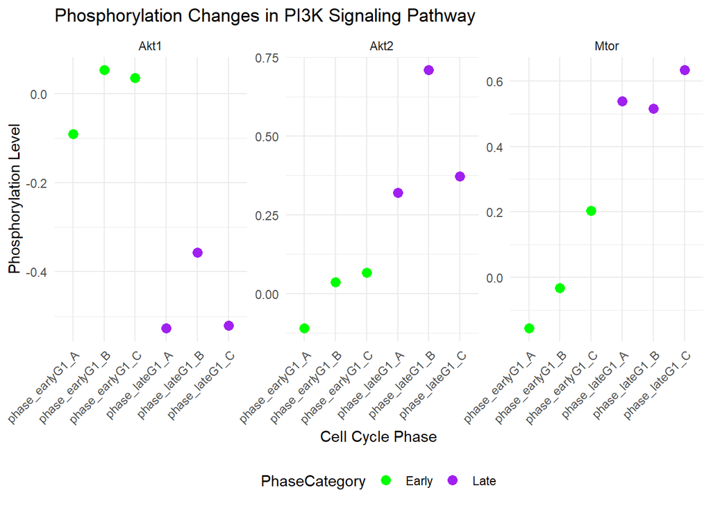

```r
phospho_data_long_pi3k <- phospho_data_long_pi3k[!is.na(phospho_data_long_pi3k$PhaseCategory), ]

# Plot phosphorylation changes for PI3K signaling
ggplot(phospho_data_long_pi3k, aes(x = Phase, y = Phosphorylation, color = PhaseCategory)) +
  geom_point(size = 3) +
  facet_wrap(~ Gene, scales = "free_y") +
  labs(title = "Phosphorylation Changes in PI3K Signaling Pathway",
       x = "Cell Cycle Phase",
       y = "Phosphorylation Level") +
  scale_color_manual(values = c("Early" = "green", "Late" = "purple")) +
  theme_minimal() +
  theme(axis.text.x = element_text(angle = 45, hjust = 1),
        legend.position = "bottom")
```

## PIK3 for LG1 to S phase

```r
# Load the data
data <- read.csv("C:/Users/avani/Downloads/Updated_Data_Mutated-June24.csv")

# Define PI3K signaling genes of interest
pi3k_signaling_genes <- c("Pik3ca", "Pik3cb", "Pik3cd", "Akt1", "Akt2", "Mtor")

# Extract phosphorylation data for PI3K signaling genes
phospho_data_pi3k <- data[data$Gene %in% pi3k_signaling_genes, ]

# Define the phases of interest (LG1 to S)
phases_of_interest <- c("phase_lateG1_A", "phase_lateG1_B", "phase_lateG1_C",
                        "phase_S_A", "phase_S_B", "phase_S_C")

# Prepare the data for plotting
phospho_data_long_pi3k <- melt(phospho_data_pi3k,
                               id.vars = c("Gene", "New_Gene_Residue"),
                               measure.vars = phases_of_interest,
                               variable.name = "Phase", value.name = "Phosphorylation")

# Create a new column to categorize phases into LG1 and S
phospho_data_long_pi3k$PhaseCategory <- ifelse(grepl("lateG1", phospho_data_long_pi3k$Phase), "LG1",
                                               ifelse(grepl("S", phospho_data_long_pi3k$Phase), "S", NA))

# Handle missing values by imputing with column means
phospho_data_long_pi3k$Phosphorylation[is.na(phospho_data_long_pi3k$Phosphorylation)] <-
  ave(phospho_data_long_pi3k$Phosphorylation, phospho_data_long_pi3k$Phase, FUN = function(x) mean(x, na.rm = TRUE))

# Check the PhaseCategory column and filter out NA values
table(phospho_data_long_pi3k$PhaseCategory)
```

```
##
## LG1   S
##   9   9
```

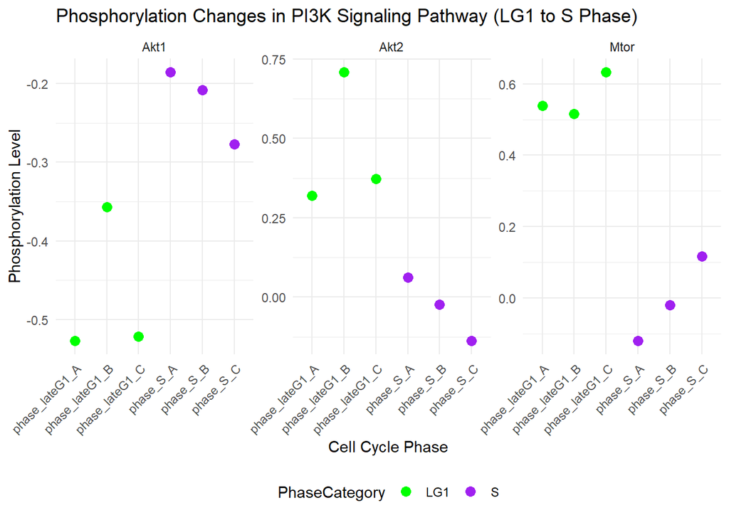

```r
phospho_data_long_pi3k <- phospho_data_long_pi3k[!is.na(phospho_data_long_pi3k$PhaseCategory), ]

# Plot phosphorylation changes for PI3K signaling
ggplot(phospho_data_long_pi3k, aes(x = Phase, y = Phosphorylation, color = PhaseCategory)) +
  geom_point(size = 3) +
  facet_wrap(~ Gene, scales = "free_y") +
  labs(title = "Phosphorylation Changes in PI3K Signaling Pathway (LG1 to S Phase)",
       x = "Cell Cycle Phase",
       y = "Phosphorylation Level") +
  scale_color_manual(values = c("LG1" = "green", "S" = "purple")) +
  theme_minimal() +
  theme(axis.text.x = element_text(angle = 45, hjust = 1),
        legend.position = "bottom")
```

## PIK3 for S to M phase

```r
# Load the data
data <- read.csv("C:/Users/avani/Downloads/Updated_Data_Mutated-June24.csv")

# Define PI3K signaling genes of interest
pi3k_signaling_genes <- c("Pik3ca", "Pik3cb", "Pik3cd", "Akt1", "Akt2", "Mtor")

# Extract phosphorylation data for PI3K signaling genes
phospho_data_pi3k <- data[data$Gene %in% pi3k_signaling_genes, ]

# Define the phases of interest (S to M)
phases_of_interest <- c("phase_S_A", "phase_S_B", "phase_S_C",
                        "phase_M_A", "phase_M_B", "phase_M_C")

# Prepare the data for plotting
phospho_data_long_pi3k <- melt(phospho_data_pi3k,
                               id.vars = c("Gene", "New_Gene_Residue"),
                               measure.vars = phases_of_interest,
                               variable.name = "Phase", value.name = "Phosphorylation")

# Create a new column to categorize phases into S and M
phospho_data_long_pi3k$PhaseCategory <- ifelse(grepl("S", phospho_data_long_pi3k$Phase), "S",
                                               ifelse(grepl("M", phospho_data_long_pi3k$Phase), "M", NA))

# Handle missing values by imputing with column means
phospho_data_long_pi3k$Phosphorylation[is.na(phospho_data_long_pi3k$Phosphorylation)] <-
  ave(phospho_data_long_pi3k$Phosphorylation, phospho_data_long_pi3k$Phase, FUN = function(x) mean(x, na.rm = TRUE))

# Check the PhaseCategory column and filter out NA values
table(phospho_data_long_pi3k$PhaseCategory)
```

```
##
## M S
## 9 9
```

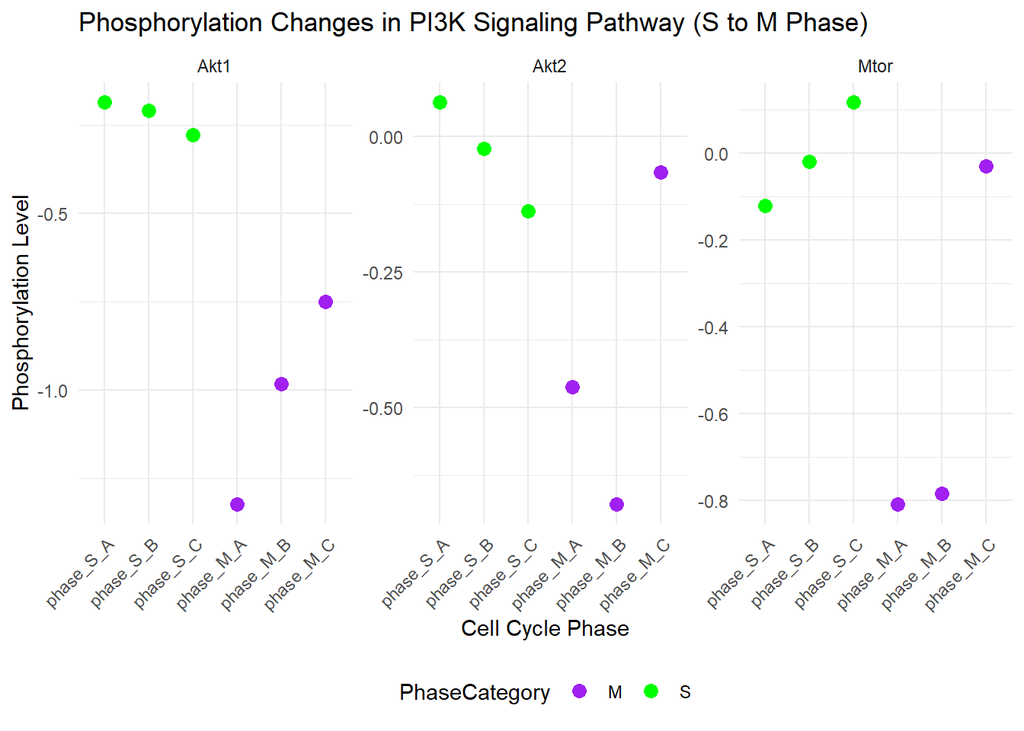

```r
phospho_data_long_pi3k <- phospho_data_long_pi3k[!is.na(phospho_data_long_pi3k$PhaseCategory), ]

# Plot phosphorylation changes for PI3K signaling
ggplot(phospho_data_long_pi3k, aes(x = Phase, y = Phosphorylation, color = PhaseCategory)) +
  geom_point(size = 3) +
  facet_wrap(~ Gene, scales = "free_y") +
  labs(title = "Phosphorylation Changes in PI3K Signaling Pathway (S to M Phase)",
       x = "Cell Cycle Phase",
       y = "Phosphorylation Level") +
  scale_color_manual(values = c("S" = "green", "M" = "purple")) +
  theme_minimal() +
  theme(axis.text.x = element_text(angle = 45, hjust = 1),
        legend.position = "bottom")
```

## PIK3 for M to EG1 phase

```r
# Load the data
data <- read.csv("C:/Users/avani/Downloads/Updated_Data_Mutated-June24.csv")

# Define PI3K signaling genes of interest
pi3k_signaling_genes <- c("Pik3ca", "Pik3cb", "Pik3cd", "Akt1", "Akt2", "Mtor")

# Extract phosphorylation data for PI3K signaling genes
phospho_data_pi3k <- data[data$Gene %in% pi3k_signaling_genes, ]

# Define the phases of interest (M to eG1)
phases_of_interest <- c("phase_M_A", "phase_M_B", "phase_M_C",
                        "phase_earlyG1_A", "phase_earlyG1_B", "phase_earlyG1_C")

# Prepare the data for plotting
phospho_data_long_pi3k <- melt(phospho_data_pi3k,
                               id.vars = c("Gene", "New_Gene_Residue"),
                               measure.vars = phases_of_interest,
                               variable.name = "Phase", value.name = "Phosphorylation")

# Create a new column to categorize phases into M and eG1
phospho_data_long_pi3k$PhaseCategory <- ifelse(grepl("M", phospho_data_long_pi3k$Phase), "M",
                                               ifelse(grepl("earlyG1", phospho_data_long_pi3k$Phase), "eG1", NA))

# Handle missing values by imputing with column means
phospho_data_long_pi3k$Phosphorylation[is.na(phospho_data_long_pi3k$Phosphorylation)] <-
  ave(phospho_data_long_pi3k$Phosphorylation, phospho_data_long_pi3k$Phase, FUN = function(x) mean(x, na.rm = TRUE))

# Check the PhaseCategory column and filter out NA values
table(phospho_data_long_pi3k$PhaseCategory)
```

```
##
## eG1   M
##   9   9
```

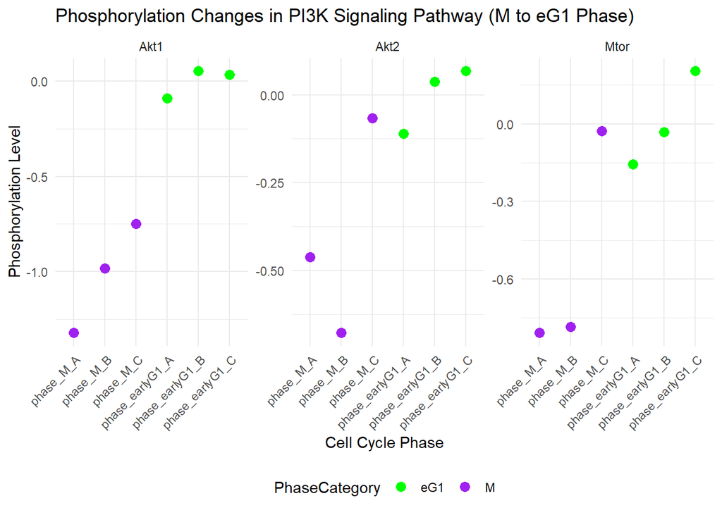

```r
phospho_data_long_pi3k <- phospho_data_long_pi3k[!is.na(phospho_data_long_pi3k$PhaseCategory), ]

# Plot phosphorylation changes for PI3K signaling
ggplot(phospho_data_long_pi3k, aes(x = Phase, y = Phosphorylation, color = PhaseCategory)) +
  geom_point(size = 3) +
  facet_wrap(~ Gene, scales = "free_y") +
  labs(title = "Phosphorylation Changes in PI3K Signaling Pathway (M to eG1 Phase)",
       x = "Cell Cycle Phase",
       y = "Phosphorylation Level") +
  scale_color_manual(values = c("M" = "purple", "eG1" = "green")) +
  theme_minimal() +
  theme(axis.text.x = element_text(angle = 45, hjust = 1),
        legend.position = "bottom")
```

## Phospho related sites among all phases for PI3K

```r
# Load necessary libraries
library(reshape2)
library(dplyr)
# Load the data
data <- read.csv("C:/Users/avani/Downloads/Updated_Data_Mutated-June24.csv")

# Define PI3K signaling genes of interest
pi3k_signaling_genes <- c("Pik3ca", "Pik3cb", "Pik3cd", "Akt1", "Akt2", "Mtor")

# Define all phases of interest
phases_of_interest <- c("phase_earlyG1_A", "phase_earlyG1_B", "phase_earlyG1_C",
                        "phase_lateG1_A", "phase_lateG1_B", "phase_lateG1_C",
                        "phase_S_A", "phase_S_B", "phase_S_C",
                        "phase_G2_A", "phase_G2_B", "phase_G2_C",
                        "phase_M_A", "phase_M_B", "phase_M_C")

# Melt the data to long format
phospho_data_long <- melt(data,
                          id.vars = c("Gene", "New_Gene_Residue", "PhosR_Rownames"),
                          measure.vars = phases_of_interest,
                          variable.name = "Phase", value.name = "Phosphorylation")

# Create a new column to categorize phases
phospho_data_long$PhaseCategory <- ifelse(grepl("earlyG1", phospho_data_long$Phase), "eG1",
                                          ifelse(grepl("lateG1", phospho_data_long$Phase), "LG1",
                                                 ifelse(grepl("S", phospho_data_long$Phase), "S",
                                                        ifelse(grepl("G2", phospho_data_long$Phase), "G2",
                                                               ifelse(grepl("M", phospho_data_long$Phase), "M", NA)))))

# Handle missing values by imputing with column means
phospho_data_long$Phosphorylation[is.na(phospho_data_long$Phosphorylation)] <-
  ave(phospho_data_long$Phosphorylation, phospho_data_long$Phase, FUN = function(x) mean(x, na.rm = TRUE))

# Check the PhaseCategory column and filter out NA values
phospho_data_long <- phospho_data_long[!is.na(phospho_data_long$PhaseCategory), ]

# Function to print phosphorylation sites and their levels for each gene
print_gene_phospho_sites <- function(gene) {
  gene_data <- phospho_data_long[phospho_data_long$Gene == gene, ]
  gene_sites <- unique(gene_data$New_Gene_Residue)

  cat("Number of unique phosphorylation sites for", gene, ":", length(gene_sites), "\n")
  cat("Phosphorylation sites for", gene, ":\n")
  print(gene_sites)

  cat("Phosphorylation levels by phase for", gene, ":\n")
  print(gene_data)
  cat("\n\n")
}

# Print phosphorylation sites and their levels for each gene
for (gene in pi3k_signaling_genes) {
  print_gene_phospho_sites(gene)
}
```

```
## Number of unique phosphorylation sites for Pik3ca : 0
## Phosphorylation sites for Pik3ca :
## character(0)
## Phosphorylation levels by phase for Pik3ca :
## [1] Gene             New_Gene_Residue PhosR_Rownames   Phase
## [5] Phosphorylation  PhaseCategory
## <0 rows> (or 0-length row.names)
##
##
## Number of unique phosphorylation sites for Pik3cb : 0
## Phosphorylation sites for Pik3cb :
## character(0)
## Phosphorylation levels by phase for Pik3cb :
## [1] Gene             New_Gene_Residue PhosR_Rownames   Phase
## [5] Phosphorylation  PhaseCategory
```

[output cut: 124 more lines]

## WNT for M EG1 to LG1 phase

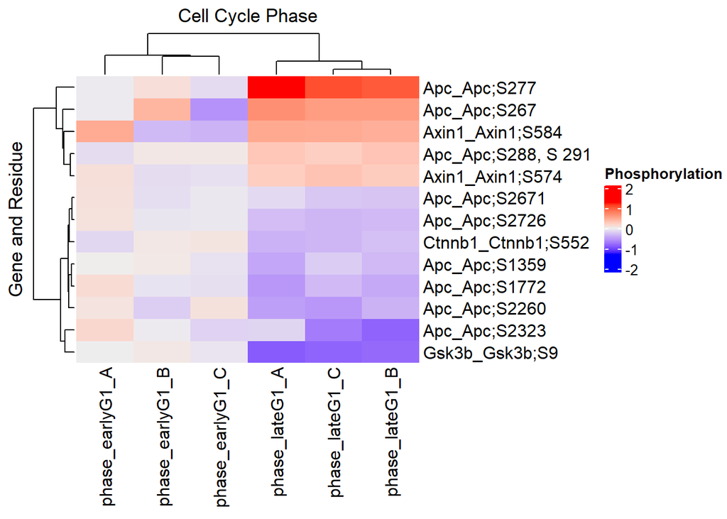

```r
library(PhosR)
library(ggplot2)
library(reshape2)
library(ComplexHeatmap)
library(circlize)

# Load the data
data <- read.csv("C:/Users/avani/Downloads/Updated_Data_Mutated-June24.csv")

# Define WNT signaling genes
wnt_signaling_genes <- c("Ctnnb1", "Apc", "Gsk3b", "Axin1", "Lef1", "Tcf7l2")

# Extract phosphorylation data for WNT signaling genes
phospho_data_wnt <- data[data$Gene %in% wnt_signaling_genes, ]

# Check if data is extracted properly
if (nrow(phospho_data_wnt) == 0) {
  stop("No data found for the specified WNT signaling genes.")
}

# Prepare the data for heatmap
phospho_data_wide_wnt <- phospho_data_wnt[, c("Gene", "New_Gene_Residue", "phase_earlyG1_A", "phase_earlyG1_B", "phase_earlyG1_C",
                                              "phase_lateG1_A", "phase_lateG1_B", "phase_lateG1_C")]
phospho_matrix_wnt <- as.matrix(phospho_data_wide_wnt[,-(1:2)])
rownames(phospho_matrix_wnt) <- paste(phospho_data_wide_wnt$Gene, phospho_data_wide_wnt$New_Gene_Residue, sep = "_")

# Create a heatmap for WNT signaling genes
Heatmap(
  phospho_matrix_wnt,
  name = "Phosphorylation",
  cluster_rows = TRUE,
  cluster_columns = TRUE,
  show_row_names = TRUE,
  show_column_names = TRUE,
  column_title = "Cell Cycle Phase",
  row_title = "Gene and Residue",
  color = colorRamp2(c(min(phospho_matrix_wnt, na.rm = TRUE), 0, max(phospho_matrix_wnt, na.rm = TRUE)), c("blue", "white", "red"))
)
```

```r
# Prepare the data for plotting
phospho_data_long_wnt <- melt(phospho_data_wnt,
                              id.vars = c("Gene", "New_Gene_Residue"),
                              measure.vars = c("phase_S_A", "phase_S_B", "phase_S_C",
                                               "phase_M_A", "phase_M_B", "phase_M_C"),
                              variable.name = "Phase", value.name = "Phospho_Values")

# Create a new column to categorize phases into S and M
phospho_data_long_wnt$PhaseCategory <- ifelse(grepl("S", phospho_data_long_wnt$Phase), "S Phase",
                                              ifelse(grepl("M", phospho_data_long_wnt$Phase), "M Phase", NA))

# Handle missing values by imputing with column means
phospho_data_long_wnt$Phospho_Values[is.na(phospho_data_long_wnt$Phospho_Values)] <-
  ave(phospho_data_long_wnt$Phospho_Values, phospho_data_long_wnt$Phase, FUN = function(x) mean(x, na.rm = TRUE))

# Check the final data for plotting
print(phospho_data_long_wnt)
```

```
##      Gene New_Gene_Residue     Phase Phospho_Values PhaseCategory
## 1   Axin1       Axin1;S574 phase_S_A    0.184610208       S Phase
## 2   Axin1       Axin1;S584 phase_S_A    0.825676518       S Phase
## 3  Ctnnb1      Ctnnb1;S552 phase_S_A   -0.417400367       S Phase
## 4     Apc        Apc;S1359 phase_S_A   -0.235851218       S Phase
## 5     Apc        Apc;S2260 phase_S_A   -0.627584250       S Phase
## 6     Apc        Apc;S2323 phase_S_A   -0.107746192       S Phase
## 7     Apc         Apc;S267 phase_S_A    1.030021745       S Phase
## 8     Apc        Apc;S2671 phase_S_A   -0.524655093       S Phase
## 9     Apc        Apc;S2726 phase_S_A   -0.242793315       S Phase
## 10    Apc         Apc;S277 phase_S_A    0.812976549       S Phase
## 11    Apc  Apc;S288, S 291 phase_S_A   -0.053014048       S Phase
## 12    Apc        Apc;S1772 phase_S_A    0.312077269       S Phase
## 13  Gsk3b         Gsk3b;S9 phase_S_A   -0.011766218       S Phase
## 14  Axin1       Axin1;S574 phase_S_B    0.051956014       S Phase
```

[output cut: 64 more lines]

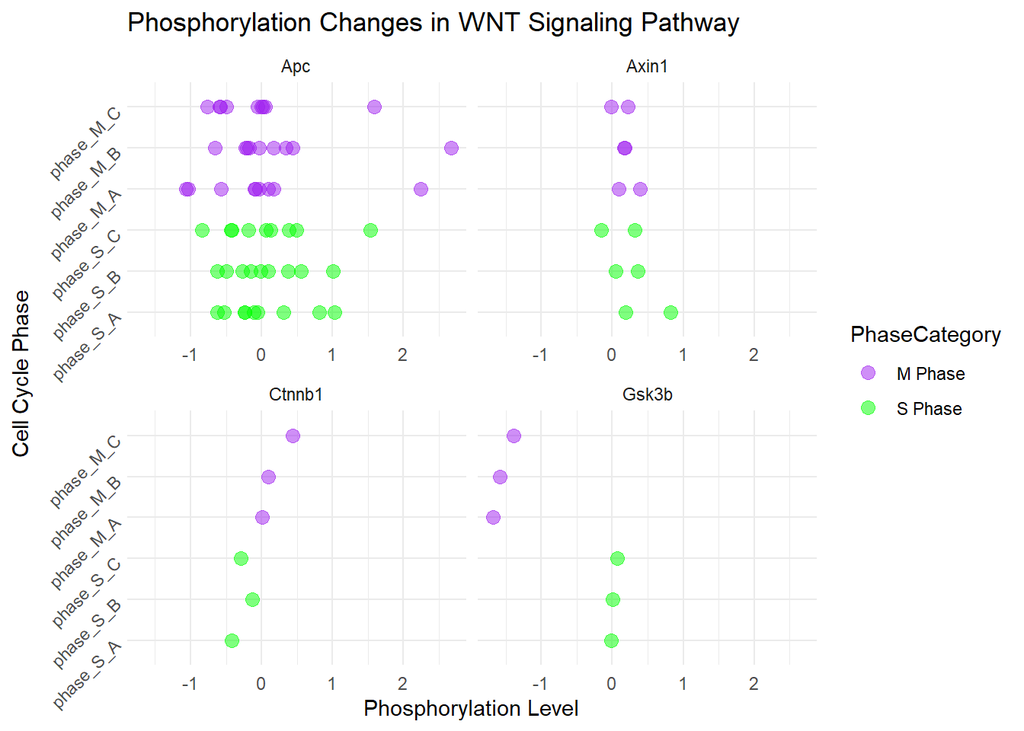

```r
# Plot phosphorylation changes for WNT signaling
ggplot(phospho_data_long_wnt, aes(y = Phase, x = Phospho_Values, color = PhaseCategory)) +
  geom_point(size = 3, alpha = 0.5) +  # Adjust alpha for transparency
  facet_wrap(~ Gene, scales = "free_x") +  # Faceting by gene
  labs(title = "Phosphorylation Changes in WNT Signaling Pathway",
       y = "Cell Cycle Phase",
       x = "Phosphorylation Level") +
  scale_color_manual(values = c("S Phase" = "green", "M Phase" = "purple")) +
  theme_minimal() +
  theme(axis.text.y = element_text(angle = 45, hjust = 1),
        legend.position = "right") +
  scale_x_continuous(limits = c(min(phospho_data_long_wnt$Phospho_Values, na.rm = TRUE),
                                max(phospho_data_long_wnt$Phospho_Values, na.rm = TRUE)))
```

## WNT for LG1 to S phase

```r
# Load the data
data <- read.csv("C:/Users/avani/Downloads/Updated_Data_Mutated-June24.csv")

# Define WNT signaling genes
wnt_signaling_genes <- c("Ctnnb1", "Apc", "Gsk3b", "Axin1", "Lef1", "Tcf7l2")

# Extract phosphorylation data for WNT signaling genes
phospho_data_wnt <- data[data$Gene %in% wnt_signaling_genes, ]

# Check if data is extracted properly
print(phospho_data_wnt)
```

```
##                        PhosR_Rownames   Gene Start  End Length
## 747   O35625;AXIN1;S574;GHAKPRSYSENAG  Axin1   574  593     19
## 748   O35625;AXIN1;T582;SENAGTTLSAGDL  Axin1   574  593     19
## 2158 Q02248;CTNNB1;T551;QDTQRRTSMGGTQ Ctnnb1   551  565     14
## 3307   Q61315;APC;S1359;FSSGAKSPSKSGA    Apc  1350 1362     12
## 3308   Q61315;APC;S2258;PLKTPASKSPSEG    Apc  2255 2272     17
## 3309   Q61315;APC;S2323;LSRPMQSPGRNSI    Apc  2306 2326     20
## 3310    Q61315;APC;S267;GHGVAESNTAASS    Apc   258  281     23
## 3311   Q61315;APC;S2671;PINNPRSGRSPTG    Apc  2671 2689     18
## 3312   Q61315;APC;S2726;LETRLNSFVQVEA    Apc  2724 2736     12
## 3313    Q61315;APC;S277;ASSSGQSPATRVD    Apc   258  281     23
## 3314    Q61315;APC;S291;ETASVLSSSGTHS    Apc   282  300     18
## 3315   Q61315;APC;T1771;TKKKKPTSPVKPM    Apc  1767 1784     17
## 8006    Q9WV60;GSK3B;T7;MSGRPRTTSFAES  Gsk3b     7   27     20
##                    DB_Peptide  Expect total_P   phase_M_A   phase_M_B
```

[output cut: 195 more lines]

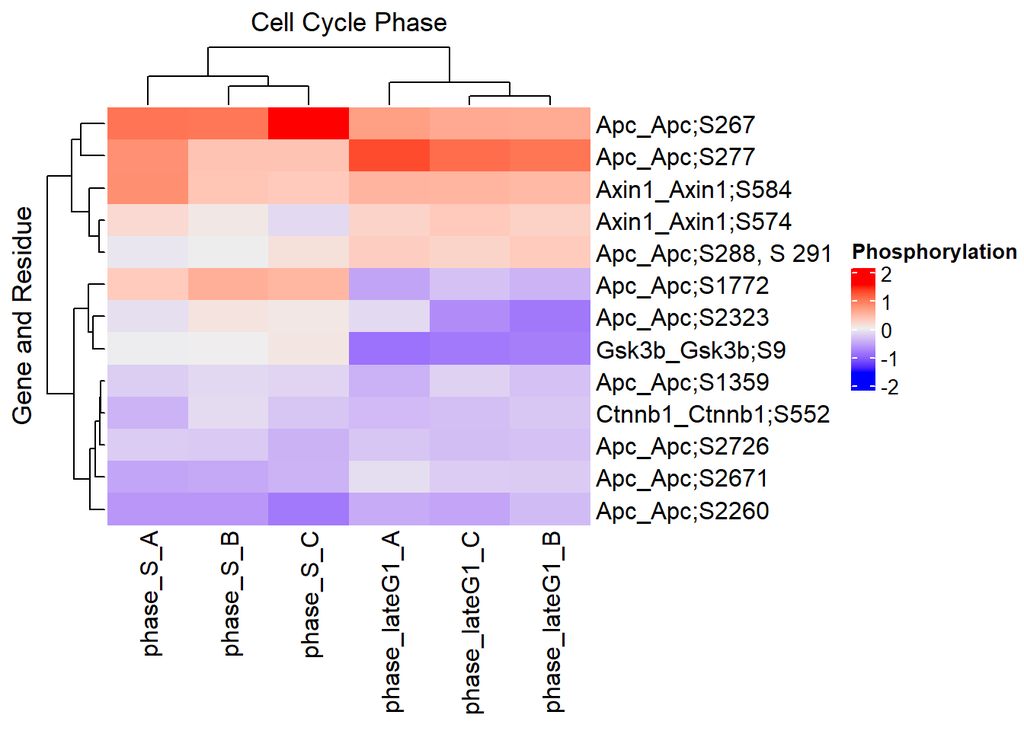

```r
# If the data frame is empty, stop here and print a message
if (nrow(phospho_data_wnt) == 0) {
  stop("No data found for the specified WNT signaling genes.")
}

# Define the phases of interest (lG1 to S)
phases_of_interest <- c("phase_lateG1_A", "phase_lateG1_B", "phase_lateG1_C",
                        "phase_S_A", "phase_S_B", "phase_S_C")

# Prepare the data for heatmap
phospho_data_wide_wnt <- phospho_data_wnt[, c("Gene", "New_Gene_Residue", phases_of_interest)]
phospho_matrix_wnt <- as.matrix(phospho_data_wide_wnt[,-(1:2)])
rownames(phospho_matrix_wnt) <- paste(phospho_data_wide_wnt$Gene, phospho_data_wide_wnt$New_Gene_Residue, sep = "_")

# Create a heatmap for WNT signaling genes
Heatmap(
  phospho_matrix_wnt,
  name = "Phosphorylation",
  cluster_rows = TRUE,
  cluster_columns = TRUE,
  show_row_names = TRUE,
  show_column_names = TRUE,
  column_title = "Cell Cycle Phase",
  row_title = "Gene and Residue",
  color = colorRamp2(c(min(phospho_matrix_wnt, na.rm = TRUE), 0, max(phospho_matrix_wnt, na.rm = TRUE)), c("blue", "white", "red"))
)
```

```r
# Prepare the data for plotting
phospho_data_long_wnt <- melt(phospho_data_wnt,
                              id.vars = c("Gene", "New_Gene_Residue"),
                              measure.vars = phases_of_interest,
                              variable.name = "Phase", value.name = "Phospho_Values")

# Check the melted data
print(phospho_data_long_wnt)
```

```
##      Gene New_Gene_Residue          Phase Phospho_Values
## 1   Axin1       Axin1;S574 phase_lateG1_A    0.244515519
## 2   Axin1       Axin1;S584 phase_lateG1_A    0.514290304
## 3  Ctnnb1      Ctnnb1;S552 phase_lateG1_A   -0.370210345
## 4     Apc        Apc;S1359 phase_lateG1_A   -0.437394840
## 5     Apc        Apc;S2260 phase_lateG1_A   -0.481869020
## 6     Apc        Apc;S2323 phase_lateG1_A   -0.150505394
## 7     Apc         Apc;S267 phase_lateG1_A    0.693132024
## 8     Apc        Apc;S2671 phase_lateG1_A   -0.122364537
## 9     Apc        Apc;S2726 phase_lateG1_A   -0.292765787
## 10    Apc         Apc;S277 phase_lateG1_A    1.297398434
## 11    Apc  Apc;S288, S 291 phase_lateG1_A    0.291634998
## 12    Apc        Apc;S1772 phase_lateG1_A   -0.527250286
## 13  Gsk3b         Gsk3b;S9 phase_lateG1_A   -0.895752358
## 14  Axin1       Axin1;S574 phase_lateG1_B    0.257954765
```

[output cut: 64 more lines]

```r
# Create a new column to categorize phases into lG1 and S
phospho_data_long_wnt$PhaseCategory <- ifelse(grepl("lateG1", phospho_data_long_wnt$Phase), "lG1", "S")

# Handle missing values by imputing with column means
phospho_data_long_wnt$Phospho_Values[is.na(phospho_data_long_wnt$Phospho_Values)] <-
  ave(phospho_data_long_wnt$Phospho_Values, phospho_data_long_wnt$Phase, FUN = function(x) mean(x, na.rm = TRUE))

# Check the final data for plotting
print(phospho_data_long_wnt)
```

```
##      Gene New_Gene_Residue          Phase Phospho_Values PhaseCategory
## 1   Axin1       Axin1;S574 phase_lateG1_A    0.244515519           lG1
## 2   Axin1       Axin1;S584 phase_lateG1_A    0.514290304           lG1
## 3  Ctnnb1      Ctnnb1;S552 phase_lateG1_A   -0.370210345           lG1
## 4     Apc        Apc;S1359 phase_lateG1_A   -0.437394840           lG1
## 5     Apc        Apc;S2260 phase_lateG1_A   -0.481869020           lG1
## 6     Apc        Apc;S2323 phase_lateG1_A   -0.150505394           lG1
## 7     Apc         Apc;S267 phase_lateG1_A    0.693132024           lG1
## 8     Apc        Apc;S2671 phase_lateG1_A   -0.122364537           lG1
## 9     Apc        Apc;S2726 phase_lateG1_A   -0.292765787           lG1
## 10    Apc         Apc;S277 phase_lateG1_A    1.297398434           lG1
## 11    Apc  Apc;S288, S 291 phase_lateG1_A    0.291634998           lG1
## 12    Apc        Apc;S1772 phase_lateG1_A   -0.527250286           lG1
## 13  Gsk3b         Gsk3b;S9 phase_lateG1_A   -0.895752358           lG1
## 14  Axin1       Axin1;S574 phase_lateG1_B    0.257954765           lG1
```

[output cut: 64 more lines]

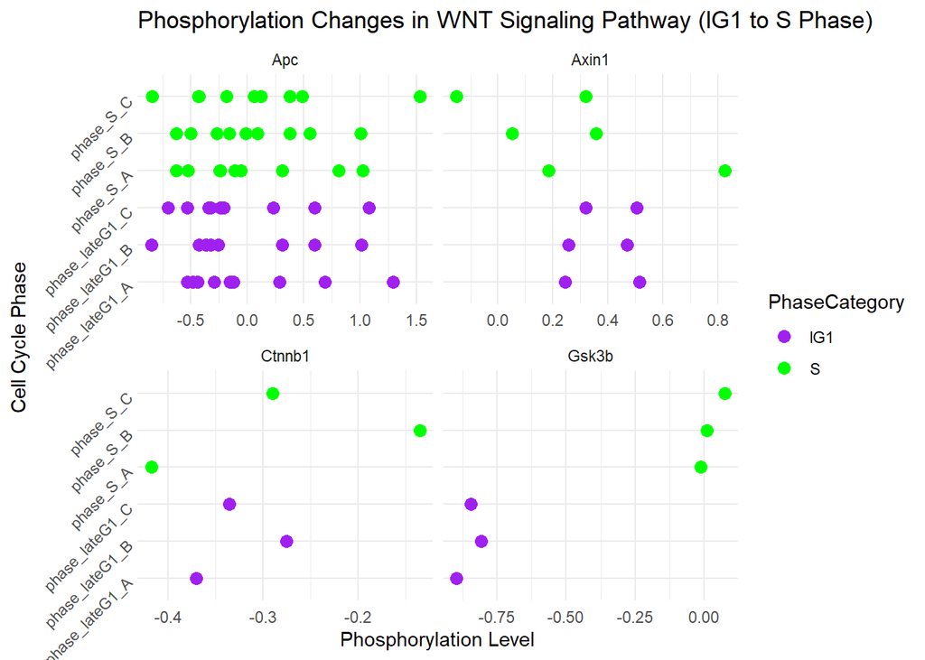

```r
# Plot phosphorylation changes for WNT signaling
ggplot(phospho_data_long_wnt, aes(y = Phase, x = Phospho_Values, color = PhaseCategory)) +
  geom_point(size = 3) +
  facet_wrap(~ Gene, scales = "free_x") +
  labs(title = "Phosphorylation Changes in WNT Signaling Pathway (lG1 to S Phase)",
       y = "Cell Cycle Phase",
       x = "Phosphorylation Level") +
  scale_color_manual(values = c("lG1" = "purple", "S" = "green")) +
  theme_minimal() +
  theme(axis.text.y = element_text(angle = 45, hjust = 1),
        legend.position = "right")
```

## WNT for S to M Phase

```r
# Load the data
data <- read.csv("C:/Users/avani/Downloads/Updated_Data_Mutated-June24.csv")

# Define WNT signaling genes
wnt_signaling_genes <- c("Ctnnb1", "Apc", "Gsk3b", "Axin1", "Lef1", "Tcf7l2")

# Extract phosphorylation data for WNT signaling genes
phospho_data_wnt <- data[data$Gene %in% wnt_signaling_genes, ]

# Check if data is extracted properly
print(phospho_data_wnt)
```

```
##                        PhosR_Rownames   Gene Start  End Length
## 747   O35625;AXIN1;S574;GHAKPRSYSENAG  Axin1   574  593     19
## 748   O35625;AXIN1;T582;SENAGTTLSAGDL  Axin1   574  593     19
## 2158 Q02248;CTNNB1;T551;QDTQRRTSMGGTQ Ctnnb1   551  565     14
## 3307   Q61315;APC;S1359;FSSGAKSPSKSGA    Apc  1350 1362     12
## 3308   Q61315;APC;S2258;PLKTPASKSPSEG    Apc  2255 2272     17
## 3309   Q61315;APC;S2323;LSRPMQSPGRNSI    Apc  2306 2326     20
## 3310    Q61315;APC;S267;GHGVAESNTAASS    Apc   258  281     23
## 3311   Q61315;APC;S2671;PINNPRSGRSPTG    Apc  2671 2689     18
## 3312   Q61315;APC;S2726;LETRLNSFVQVEA    Apc  2724 2736     12
## 3313    Q61315;APC;S277;ASSSGQSPATRVD    Apc   258  281     23
## 3314    Q61315;APC;S291;ETASVLSSSGTHS    Apc   282  300     18
## 3315   Q61315;APC;T1771;TKKKKPTSPVKPM    Apc  1767 1784     17
## 8006    Q9WV60;GSK3B;T7;MSGRPRTTSFAES  Gsk3b     7   27     20
##                    DB_Peptide  Expect total_P   phase_M_A   phase_M_B
```

[output cut: 195 more lines]

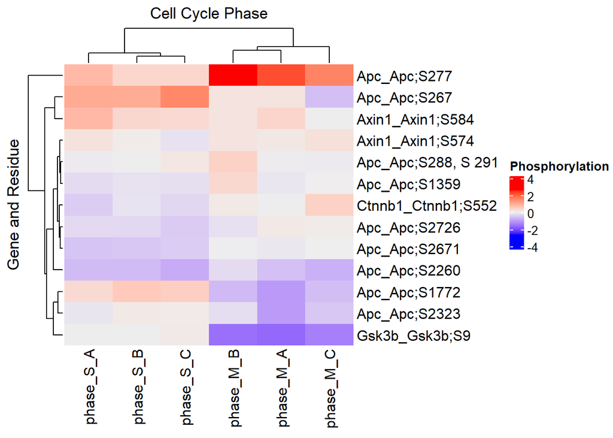

```r
# If the data frame is empty, stop here and print a message
if (nrow(phospho_data_wnt) == 0) {
  stop("No data found for the specified WNT signaling genes.")
}

# Define the phases of interest (S to M)
phases_of_interest <- c("phase_S_A", "phase_S_B", "phase_S_C",
                        "phase_M_A", "phase_M_B", "phase_M_C")

# Prepare the data for heatmap
phospho_data_wide_wnt <- phospho_data_wnt[, c("Gene", "New_Gene_Residue", phases_of_interest)]
phospho_matrix_wnt <- as.matrix(phospho_data_wide_wnt[,-(1:2)])
rownames(phospho_matrix_wnt) <- paste(phospho_data_wide_wnt$Gene, phospho_data_wide_wnt$New_Gene_Residue, sep = "_")

# Create a heatmap for WNT signaling genes
Heatmap(
  phospho_matrix_wnt,
  name = "Phosphorylation",
  cluster_rows = TRUE,
  cluster_columns = TRUE,
  show_row_names = TRUE,
  show_column_names = TRUE,
  column_title = "Cell Cycle Phase",
  row_title = "Gene and Residue",
  color = colorRamp2(c(min(phospho_matrix_wnt, na.rm = TRUE), 0, max(phospho_matrix_wnt, na.rm = TRUE)), c("blue", "white", "red"))
)
```

```r
# Prepare the data for plotting
phospho_data_long_wnt <- melt(phospho_data_wnt,
                              id.vars = c("Gene", "New_Gene_Residue"),
                              measure.vars = phases_of_interest,
                              variable.name = "Phase", value.name = "Phospho_Values")

# Check the melted data
print(phospho_data_long_wnt)
```

```
##      Gene New_Gene_Residue     Phase Phospho_Values
## 1   Axin1       Axin1;S574 phase_S_A    0.184610208
## 2   Axin1       Axin1;S584 phase_S_A    0.825676518
## 3  Ctnnb1      Ctnnb1;S552 phase_S_A   -0.417400367
## 4     Apc        Apc;S1359 phase_S_A   -0.235851218
## 5     Apc        Apc;S2260 phase_S_A   -0.627584250
## 6     Apc        Apc;S2323 phase_S_A   -0.107746192
## 7     Apc         Apc;S267 phase_S_A    1.030021745
## 8     Apc        Apc;S2671 phase_S_A   -0.524655093
## 9     Apc        Apc;S2726 phase_S_A   -0.242793315
## 10    Apc         Apc;S277 phase_S_A    0.812976549
## 11    Apc  Apc;S288, S 291 phase_S_A   -0.053014048
## 12    Apc        Apc;S1772 phase_S_A    0.312077269
## 13  Gsk3b         Gsk3b;S9 phase_S_A   -0.011766218
## 14  Axin1       Axin1;S574 phase_S_B    0.051956014
```

[output cut: 64 more lines]

```r
# Create a new column to categorize phases into S and M
phospho_data_long_wnt$PhaseCategory <- ifelse(grepl("S", phospho_data_long_wnt$Phase), "S", "M")

# Handle missing values by imputing with column means
phospho_data_long_wnt$Phospho_Values[is.na(phospho_data_long_wnt$Phospho_Values)] <-
  ave(phospho_data_long_wnt$Phospho_Values, phospho_data_long_wnt$Phase, FUN = function(x) mean(x, na.rm = TRUE))

# Check the final data for plotting
print(phospho_data_long_wnt)
```

```
##      Gene New_Gene_Residue     Phase Phospho_Values PhaseCategory
## 1   Axin1       Axin1;S574 phase_S_A    0.184610208             S
## 2   Axin1       Axin1;S584 phase_S_A    0.825676518             S
## 3  Ctnnb1      Ctnnb1;S552 phase_S_A   -0.417400367             S
## 4     Apc        Apc;S1359 phase_S_A   -0.235851218             S
## 5     Apc        Apc;S2260 phase_S_A   -0.627584250             S
## 6     Apc        Apc;S2323 phase_S_A   -0.107746192             S
## 7     Apc         Apc;S267 phase_S_A    1.030021745             S
## 8     Apc        Apc;S2671 phase_S_A   -0.524655093             S
## 9     Apc        Apc;S2726 phase_S_A   -0.242793315             S
## 10    Apc         Apc;S277 phase_S_A    0.812976549             S
## 11    Apc  Apc;S288, S 291 phase_S_A   -0.053014048             S
## 12    Apc        Apc;S1772 phase_S_A    0.312077269             S
## 13  Gsk3b         Gsk3b;S9 phase_S_A   -0.011766218             S
## 14  Axin1       Axin1;S574 phase_S_B    0.051956014             S
```

[output cut: 64 more lines]

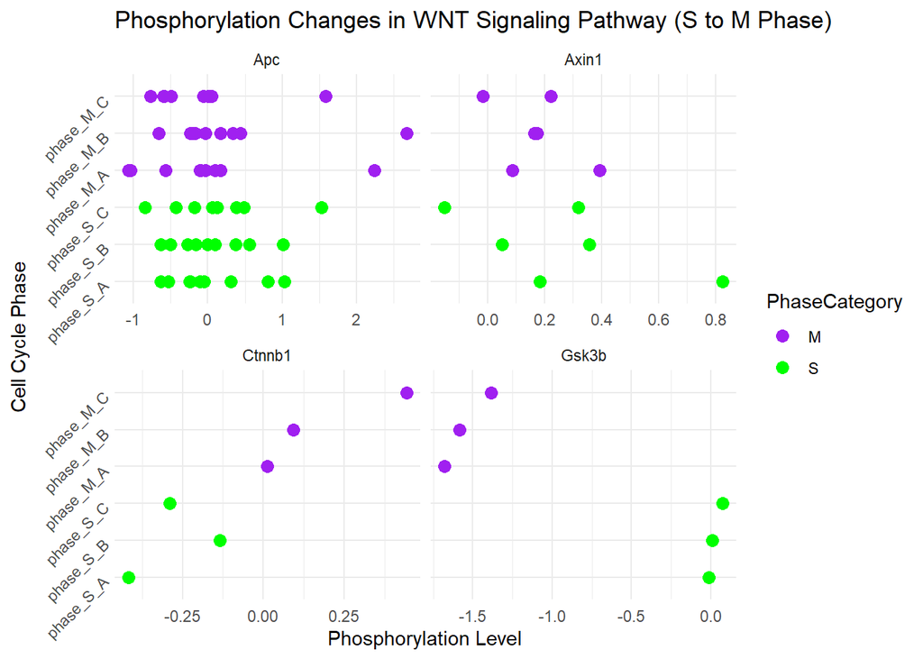

```r
# Plot phosphorylation changes for WNT signaling
ggplot(phospho_data_long_wnt, aes(y = Phase, x = Phospho_Values, color = PhaseCategory)) +
  geom_point(size = 3) +
  facet_wrap(~ Gene, scales = "free_x") +
  labs(title = "Phosphorylation Changes in WNT Signaling Pathway (S to M Phase)",
       y = "Cell Cycle Phase",
       x = "Phosphorylation Level") +
  scale_color_manual(values = c("S" = "green", "M" = "purple")) +
  theme_minimal() +
  theme(axis.text.y = element_text(angle = 45, hjust = 1),
        legend.position = "right")
```

## WNT for M to LG1 phase

```r
# Load the data
data <- read.csv("C:/Users/avani/Downloads/Updated_Data_Mutated-June24.csv")

# Define WNT signaling genes
wnt_signaling_genes <- c("Ctnnb1", "Apc", "Gsk3b", "Axin1", "Lef1", "Tcf7l2")

# Extract phosphorylation data for WNT signaling genes
phospho_data_wnt <- data[data$Gene %in% wnt_signaling_genes, ]

# Check if data is extracted properly
print(phospho_data_wnt)
```

```
##                        PhosR_Rownames   Gene Start  End Length
## 747   O35625;AXIN1;S574;GHAKPRSYSENAG  Axin1   574  593     19
## 748   O35625;AXIN1;T582;SENAGTTLSAGDL  Axin1   574  593     19
## 2158 Q02248;CTNNB1;T551;QDTQRRTSMGGTQ Ctnnb1   551  565     14
## 3307   Q61315;APC;S1359;FSSGAKSPSKSGA    Apc  1350 1362     12
## 3308   Q61315;APC;S2258;PLKTPASKSPSEG    Apc  2255 2272     17
## 3309   Q61315;APC;S2323;LSRPMQSPGRNSI    Apc  2306 2326     20
## 3310    Q61315;APC;S267;GHGVAESNTAASS    Apc   258  281     23
## 3311   Q61315;APC;S2671;PINNPRSGRSPTG    Apc  2671 2689     18
## 3312   Q61315;APC;S2726;LETRLNSFVQVEA    Apc  2724 2736     12
## 3313    Q61315;APC;S277;ASSSGQSPATRVD    Apc   258  281     23
## 3314    Q61315;APC;S291;ETASVLSSSGTHS    Apc   282  300     18
## 3315   Q61315;APC;T1771;TKKKKPTSPVKPM    Apc  1767 1784     17
## 8006    Q9WV60;GSK3B;T7;MSGRPRTTSFAES  Gsk3b     7   27     20
##                    DB_Peptide  Expect total_P   phase_M_A   phase_M_B
```

[output cut: 195 more lines]

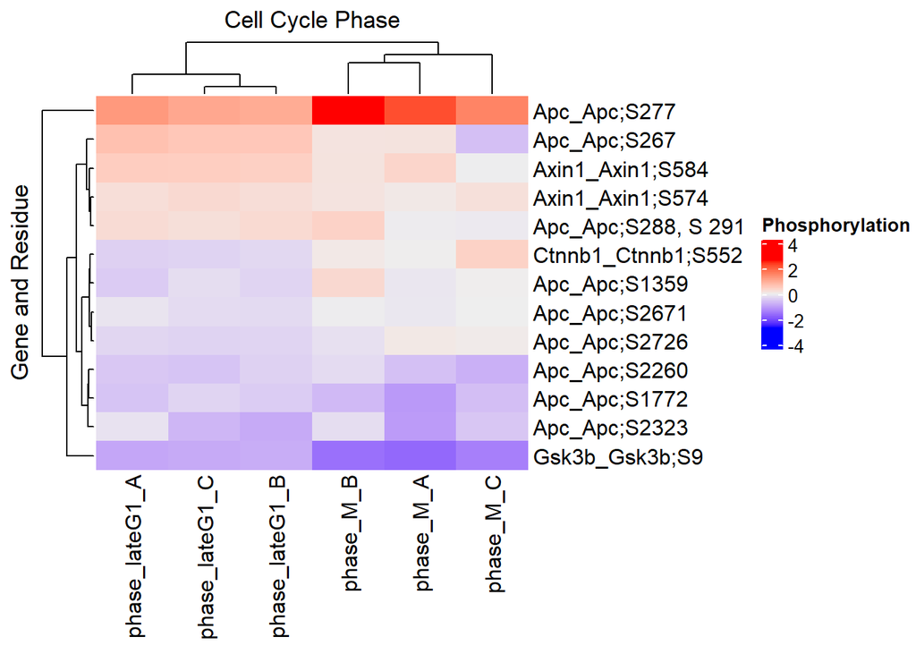

```r
# If the data frame is empty, stop here and print a message
if (nrow(phospho_data_wnt) == 0) {
  stop("No data found for the specified WNT signaling genes.")
}

# Define the phases of interest (M to LG1)
phases_of_interest <- c("phase_M_A", "phase_M_B", "phase_M_C",
                        "phase_lateG1_A", "phase_lateG1_B", "phase_lateG1_C")

# Prepare the data for heatmap
phospho_data_wide_wnt <- phospho_data_wnt[, c("Gene", "New_Gene_Residue", phases_of_interest)]
phospho_matrix_wnt <- as.matrix(phospho_data_wide_wnt[,-(1:2)])
rownames(phospho_matrix_wnt) <- paste(phospho_data_wide_wnt$Gene, phospho_data_wide_wnt$New_Gene_Residue, sep = "_")

# Create a heatmap for WNT signaling genes
Heatmap(
  phospho_matrix_wnt,
  name = "Phosphorylation",
  cluster_rows = TRUE,
  cluster_columns = TRUE,
  show_row_names = TRUE,
  show_column_names = TRUE,
  column_title = "Cell Cycle Phase",
  row_title = "Gene and Residue",
  color = colorRamp2(c(min(phospho_matrix_wnt, na.rm = TRUE), 0, max(phospho_matrix_wnt, na.rm = TRUE)), c("blue", "white", "red"))
)
```

```r
# Prepare the data for plotting
phospho_data_long_wnt <- melt(phospho_data_wnt,
                              id.vars = c("Gene", "New_Gene_Residue"),
                              measure.vars = phases_of_interest,
                              variable.name = "Phase", value.name = "Phospho_Values")

# Check the melted data
print(phospho_data_long_wnt)
```

```
##      Gene New_Gene_Residue          Phase Phospho_Values
## 1   Axin1       Axin1;S574      phase_M_A    0.087029972
## 2   Axin1       Axin1;S584      phase_M_A    0.393017321
## 3  Ctnnb1      Ctnnb1;S552      phase_M_A    0.012263847
## 4     Apc        Apc;S1359      phase_M_A   -0.101796854
## 5     Apc        Apc;S2260      phase_M_A   -0.565423234
## 6     Apc        Apc;S2323      phase_M_A   -1.034352475
## 7     Apc         Apc;S267      phase_M_A    0.173638544
## 8     Apc        Apc;S2671      phase_M_A   -0.090869004
## 9     Apc        Apc;S2726      phase_M_A    0.096120334
## 10    Apc         Apc;S277      phase_M_A    2.241502370
## 11    Apc  Apc;S288, S 291      phase_M_A   -0.031831151
## 12    Apc        Apc;S1772      phase_M_A   -1.065749126
## 13  Gsk3b         Gsk3b;S9      phase_M_A   -1.678608860
## 14  Axin1       Axin1;S574      phase_M_B    0.165560524
```

[output cut: 64 more lines]

```r
# Create a new column to categorize phases into M and LG1
phospho_data_long_wnt$PhaseCategory <- ifelse(grepl("M", phospho_data_long_wnt$Phase), "M", "LG1")

# Handle missing values by imputing with column means
phospho_data_long_wnt$Phospho_Values[is.na(phospho_data_long_wnt$Phospho_Values)] <-
  ave(phospho_data_long_wnt$Phospho_Values, phospho_data_long_wnt$Phase, FUN = function(x) mean(x, na.rm = TRUE))

# Check the final data for plotting
print(phospho_data_long_wnt)
```

```
##      Gene New_Gene_Residue          Phase Phospho_Values PhaseCategory
## 1   Axin1       Axin1;S574      phase_M_A    0.087029972             M
## 2   Axin1       Axin1;S584      phase_M_A    0.393017321             M
## 3  Ctnnb1      Ctnnb1;S552      phase_M_A    0.012263847             M
## 4     Apc        Apc;S1359      phase_M_A   -0.101796854             M
## 5     Apc        Apc;S2260      phase_M_A   -0.565423234             M
## 6     Apc        Apc;S2323      phase_M_A   -1.034352475             M
## 7     Apc         Apc;S267      phase_M_A    0.173638544             M
## 8     Apc        Apc;S2671      phase_M_A   -0.090869004             M
## 9     Apc        Apc;S2726      phase_M_A    0.096120334             M
## 10    Apc         Apc;S277      phase_M_A    2.241502370             M
## 11    Apc  Apc;S288, S 291      phase_M_A   -0.031831151             M
## 12    Apc        Apc;S1772      phase_M_A   -1.065749126             M
## 13  Gsk3b         Gsk3b;S9      phase_M_A   -1.678608860             M
## 14  Axin1       Axin1;S574      phase_M_B    0.165560524             M
```

[output cut: 64 more lines]

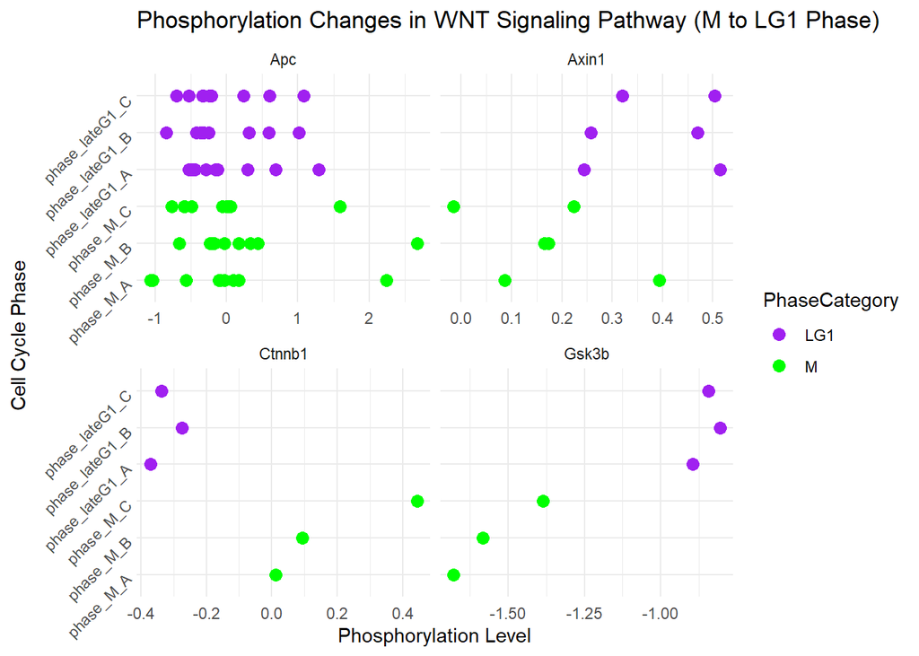

```r
# Plot phosphorylation changes for WNT signaling
ggplot(phospho_data_long_wnt, aes(y = Phase, x = Phospho_Values, color = PhaseCategory)) +
  geom_point(size = 3) +
  facet_wrap(~ Gene, scales = "free_x") +
  labs(title = "Phosphorylation Changes in WNT Signaling Pathway (M to LG1 Phase)",
       y = "Cell Cycle Phase",
       x = "Phosphorylation Level") +
  scale_color_manual(values = c("M" = "green", "LG1" = "purple")) +
  theme_minimal() +
  theme(axis.text.y = element_text(angle = 45, hjust = 1),
        legend.position = "right")
```

## phospho related sites among all phases for WNT

```r
# Load necessary libraries
library(reshape2)
library(ggplot2)
library(ComplexHeatmap)
library(circlize)

# Load the data
data <- read.csv("C:/Users/avani/Downloads/Updated_Data_Mutated-June24.csv")

# Define WNT signaling genes
wnt_signaling_genes <- c("Ctnnb1", "Apc", "Gsk3b", "Axin1", "Lef1", "Tcf7l2")

# Extract phosphorylation data for WNT signaling genes
phospho_data_wnt <- data[data$Gene %in% wnt_signaling_genes, ]

# Check if data is extracted properly
print(phospho_data_wnt)
```

```
##                        PhosR_Rownames   Gene Start  End Length
## 747   O35625;AXIN1;S574;GHAKPRSYSENAG  Axin1   574  593     19
## 748   O35625;AXIN1;T582;SENAGTTLSAGDL  Axin1   574  593     19
## 2158 Q02248;CTNNB1;T551;QDTQRRTSMGGTQ Ctnnb1   551  565     14
## 3307   Q61315;APC;S1359;FSSGAKSPSKSGA    Apc  1350 1362     12
## 3308   Q61315;APC;S2258;PLKTPASKSPSEG    Apc  2255 2272     17
## 3309   Q61315;APC;S2323;LSRPMQSPGRNSI    Apc  2306 2326     20
## 3310    Q61315;APC;S267;GHGVAESNTAASS    Apc   258  281     23
## 3311   Q61315;APC;S2671;PINNPRSGRSPTG    Apc  2671 2689     18
## 3312   Q61315;APC;S2726;LETRLNSFVQVEA    Apc  2724 2736     12
## 3313    Q61315;APC;S277;ASSSGQSPATRVD    Apc   258  281     23
## 3314    Q61315;APC;S291;ETASVLSSSGTHS    Apc   282  300     18
## 3315   Q61315;APC;T1771;TKKKKPTSPVKPM    Apc  1767 1784     17
## 8006    Q9WV60;GSK3B;T7;MSGRPRTTSFAES  Gsk3b     7   27     20
##                    DB_Peptide  Expect total_P   phase_M_A   phase_M_B
```

[output cut: 195 more lines]

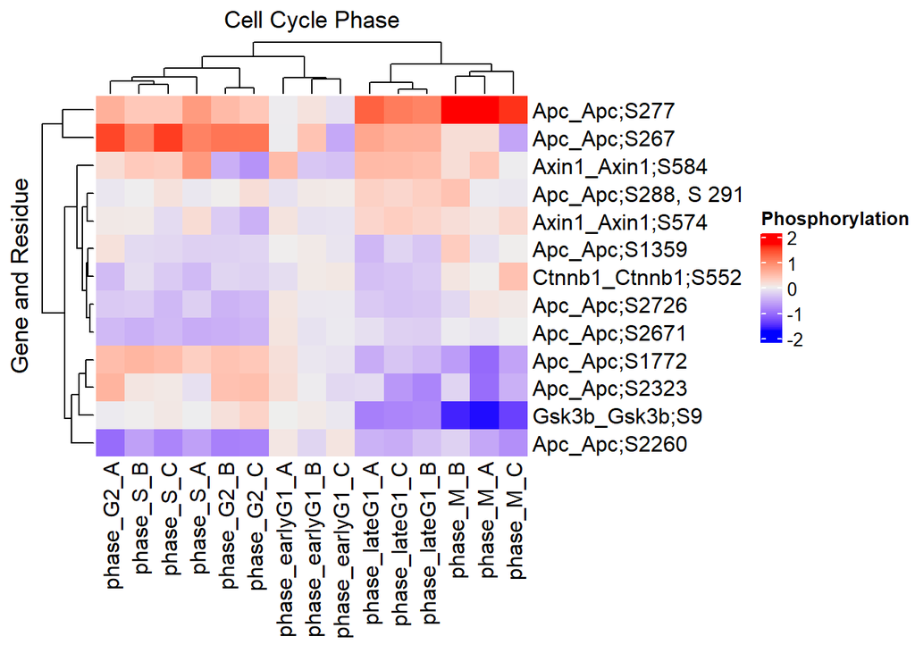

```r
# If the data frame is empty, stop here and print a message
if (nrow(phospho_data_wnt) == 0) {
  stop("No data found for the specified WNT signaling genes.")
}

# Define all phases of interest
phases_of_interest <- c("phase_earlyG1_A", "phase_earlyG1_B", "phase_earlyG1_C",
                        "phase_lateG1_A", "phase_lateG1_B", "phase_lateG1_C",
                        "phase_S_A", "phase_S_B", "phase_S_C",
                        "phase_G2_A", "phase_G2_B", "phase_G2_C",
                        "phase_M_A", "phase_M_B", "phase_M_C")

# Prepare the data for heatmap
phospho_data_wide_wnt <- phospho_data_wnt[, c("Gene", "New_Gene_Residue", phases_of_interest)]
phospho_matrix_wnt <- as.matrix(phospho_data_wide_wnt[,-(1:2)])
rownames(phospho_matrix_wnt) <- paste(phospho_data_wide_wnt$Gene, phospho_data_wide_wnt$New_Gene_Residue, sep = "_")

# Create a heatmap for WNT signaling genes
Heatmap(
  phospho_matrix_wnt,
  name = "Phosphorylation",
  cluster_rows = TRUE,
  cluster_columns = TRUE,
  show_row_names = TRUE,
  show_column_names = TRUE,
  column_title = "Cell Cycle Phase",
  row_title = "Gene and Residue",
  color = colorRamp2(c(min(phospho_matrix_wnt, na.rm = TRUE), 0, max(phospho_matrix_wnt, na.rm = TRUE)), c("blue", "white", "red"))
)
```

```r
# Prepare the data for plotting
phospho_data_long_wnt <- melt(phospho_data_wnt,
                              id.vars = c("Gene", "New_Gene_Residue"),
                              measure.vars = phases_of_interest,
                              variable.name = "Phase", value.name = "Phospho_Values")

# Create a new column to categorize phases
phospho_data_long_wnt$PhaseCategory <- ifelse(grepl("earlyG1", phospho_data_long_wnt$Phase), "earlyG1",
                                              ifelse(grepl("lateG1", phospho_data_long_wnt$Phase), "lateG1",
                                                     ifelse(grepl("S", phospho_data_long_wnt$Phase), "S",
                                                            ifelse(grepl("G2", phospho_data_long_wnt$Phase), "G2",
                                                                   ifelse(grepl("M", phospho_data_long_wnt$Phase), "M", NA)))))

# Handle missing values by imputing with column means
phospho_data_long_wnt$Phospho_Values[is.na(phospho_data_long_wnt$Phospho_Values)] <-
  ave(phospho_data_long_wnt$Phospho_Values, phospho_data_long_wnt$Phase, FUN = function(x) mean(x, na.rm = TRUE))

# Check the final data for plotting
print(phospho_data_long_wnt)
```

```
##       Gene New_Gene_Residue           Phase Phospho_Values PhaseCategory
## 1    Axin1       Axin1;S574 phase_earlyG1_A    0.113357624       earlyG1
## 2    Axin1       Axin1;S584 phase_earlyG1_A    0.500580189       earlyG1
## 3   Ctnnb1      Ctnnb1;S552 phase_earlyG1_A   -0.138337854       earlyG1
## 4      Apc        Apc;S1359 phase_earlyG1_A    0.010143573       earlyG1
## 5      Apc        Apc;S2260 phase_earlyG1_A    0.081462882       earlyG1
## 6      Apc        Apc;S2323 phase_earlyG1_A    0.172599325       earlyG1
## 7      Apc         Apc;S267 phase_earlyG1_A   -0.025199316       earlyG1
## 8      Apc        Apc;S2671 phase_earlyG1_A    0.103291295       earlyG1
## 9      Apc        Apc;S2726 phase_earlyG1_A    0.089044316       earlyG1
## 10     Apc         Apc;S277 phase_earlyG1_A   -0.022750123       earlyG1
## 11     Apc  Apc;S288, S 291 phase_earlyG1_A   -0.105113939       earlyG1
## 12     Apc        Apc;S1772 phase_earlyG1_A    0.146924639       earlyG1
## 13   Gsk3b         Gsk3b;S9 phase_earlyG1_A    0.004513452       earlyG1
## 14   Axin1       Axin1;S574 phase_earlyG1_B   -0.106729569       earlyG1
```

[output cut: 181 more lines]

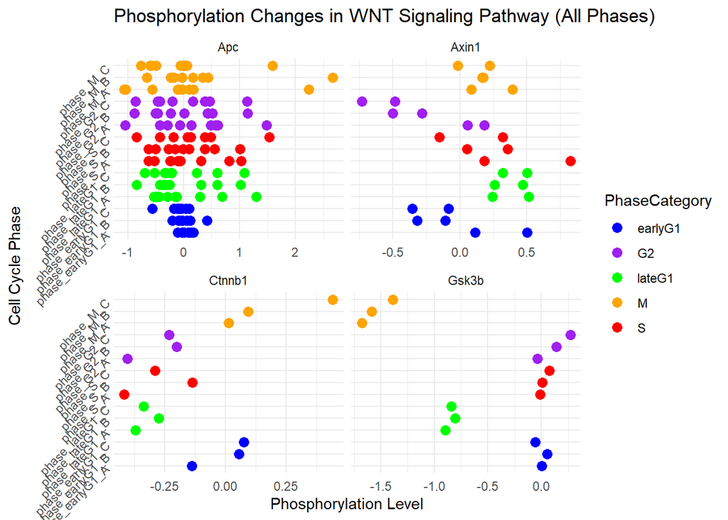

```r
# Plot phosphorylation changes for WNT signaling
ggplot(phospho_data_long_wnt, aes(y = Phase, x = Phospho_Values, color = PhaseCategory)) +
  geom_point(size = 3) +
  facet_wrap(~ Gene, scales = "free_x") +
  labs(title = "Phosphorylation Changes in WNT Signaling Pathway (All Phases)",
       y = "Cell Cycle Phase",
       x = "Phosphorylation Level") +
  scale_color_manual(values = c("earlyG1" = "blue", "lateG1" = "green", "S" = "red", "G2" = "purple", "M" = "orange")) +
  theme_minimal() +
  theme(axis.text.y = element_text(angle = 45, hjust = 1),
        legend.position = "right")
```

```r
# Function to print phosphorylation sites and their levels for each gene
print_gene_phospho_sites <- function(gene) {
  gene_data <- phospho_data_long_wnt[phospho_data_long_wnt$Gene == gene, ]
  gene_sites <- unique(gene_data$New_Gene_Residue)

  cat("Number of unique phosphorylation sites for", gene, ":", length(gene_sites), "\n")
  cat("Phosphorylation sites for", gene, ":\n")
  print(gene_sites)

  cat("Phosphorylation levels by phase for", gene, ":\n")
  print(gene_data)
  cat("\n\n")
}

# Print phosphorylation sites and their levels for each WNT signaling gene
for (gene in wnt_signaling_genes) {
  print_gene_phospho_sites(gene)
}
```

```
## Number of unique phosphorylation sites for Ctnnb1 : 1
## Phosphorylation sites for Ctnnb1 :
## [1] "Ctnnb1;S552"
## Phosphorylation levels by phase for Ctnnb1 :
##       Gene New_Gene_Residue           Phase Phospho_Values PhaseCategory
## 3   Ctnnb1      Ctnnb1;S552 phase_earlyG1_A    -0.13833785       earlyG1
## 16  Ctnnb1      Ctnnb1;S552 phase_earlyG1_B     0.05488460       earlyG1
## 29  Ctnnb1      Ctnnb1;S552 phase_earlyG1_C     0.07494670       earlyG1
## 42  Ctnnb1      Ctnnb1;S552  phase_lateG1_A    -0.37021034        lateG1
## 55  Ctnnb1      Ctnnb1;S552  phase_lateG1_B    -0.27505593        lateG1
## 68  Ctnnb1      Ctnnb1;S552  phase_lateG1_C    -0.33583413        lateG1
## 81  Ctnnb1      Ctnnb1;S552       phase_S_A    -0.41740037             S
## 94  Ctnnb1      Ctnnb1;S552       phase_S_B    -0.13507089             S
## 107 Ctnnb1      Ctnnb1;S552       phase_S_C    -0.28993729             S
## 120 Ctnnb1      Ctnnb1;S552      phase_G2_A    -0.40402770            G2
```

[output cut: 226 more lines]